# STA623 - Bayesian Data Analysis

- Show All Code
- Hide All Code
- View Source

Lecture notes

Author

Marc Henrion

Published

October 2026

# 1 Preliminaries

## 1.1 How this course is organised

The course is built around one idea: **a Bayesian analysis is a posterior distribution, and in practice we obtain posterior distributions by computing, not by integrating by hand.** Mathematics is kept to what you need to understand *what* the computer is doing and *why* it can go wrong.

| Lecture | Topic | Main computational tool | Practical |
| --- | --- | --- | --- |
| 1 | Bayesian reasoning: prior, likelihood, posterior | Grid approximation | 1 |
| 2 | Priors, conjugate models, posterior summaries & prediction | Exact formulae + simulation | 2 |
| 3 | Monte Carlo and Markov chain Monte Carlo | Hand-written Metropolis & Gibbs samplers in `R` | 3 |
| 4 | MCMC in practice: `NIMBLE` and convergence diagnostics | `NIMBLE`, `posterior` | 4 |
| 5 | Bayesian regression, model checking, comparison, hierarchical models | `NIMBLE`, `loo` | 5 |

Longer derivations (conjugate posteriors, Jeffreys priors, the full normal model, loss functions) are in the **appendices**. They are useful for understanding and for self-study, but you are not expected to reproduce them in the exam.

- All code is `R`; Bayesian models are specified in `NIMBLE` (a dialect of `BUGS`).
- `R` packages used: `tidyverse`, `gridExtra`, `HDInterval`, `nimble`, `coda`, `posterior`, `loo` (plus `MCMCvis` optionally). Install them all before the first practical: `NIMBLE` needs a working C++ compiler (Rtools on Windows, Xcode command line tools on macOS).
- Course materials: https://github.com/gitMarcH/UNIMA_STA623_2025

## 1.2 References

Core texts:

1. Hoff, P.D. (2009). *A First Course in Bayesian Statistical Methods*. Springer.
2. McElreath, R. (2020). *Statistical Rethinking*. 2<sup>nd</sup> ed. CRC Press. (Very accessible, computation-first.)
3. Johnson, A.A., Ott, M.Q., Dogucu, M. (2022). *Bayes Rules! An Introduction to Applied Bayesian Modeling*. CRC Press. Free online: https://www.bayesrulesbook.com
4. Gelman, A., Carlin, J.B., Stern, H.S., Dunson, D.B., Vehtari, A., Rubin, D.B. (2013). *Bayesian Data Analysis*. 3<sup>rd</sup> ed. CRC Press. (Reference text; free PDF from the authors’ website.)

Papers you will meet in Lectures 4 and 5:

5. Gelman, A. et al. (2020). Bayesian workflow. *arXiv:2011.01808*.
6. Vehtari, A., Gelman, A., Simpson, D., Carpenter, B., Bürkner, P.-C. (2021). Rank-normalization, folding, and localization: an improved $\widehat{R}$ for assessing convergence of MCMC. *Bayesian Analysis* 16(2), 667-718.
7. Vehtari, A., Gelman, A., Gabry, J. (2017). Practical Bayesian model evaluation using leave-one-out cross-validation and WAIC. *Statistics and Computing* 27, 1413-1432.
8. de Valpine, P. et al. (2017). Programming with models: writing statistical algorithms for general model structures with NIMBLE. *J. Comput. Graph. Stat.* 26(2), 403-413.
9. Kruschke, J.K. (2021). Bayesian analysis reporting guidelines. *Nature Human Behaviour* 5, 1282-1291.

## 1.3 Notation

- $Y, Y_1,\ldots,Y_n$: random variables (data before they are observed); $y, y_1,\ldots,y_n$: observed values. $\mathbf{y}=(y_1,\ldots,y_n)$.
- $\theta$: a generic parameter (or vector of parameters).
- $p(\cdot)$: a probability mass or density function; which one is meant is clear from its argument. $p(\theta)$ is the prior, $p(y\mid\theta)$ the sampling model / likelihood, $p(\theta\mid y)$ the posterior.
- $\theta^{(1)},\ldots,\theta^{(S)}$: $S$ simulated draws of $\theta$.
- $E[\cdot]$, $\text{Var}(\cdot)$: expectation and variance. $\sim_{\text{iid}}$: independent and identically distributed.
- Distributions are parameterised as in `R` unless stated otherwise, e.g. $\text{Gamma}(a,b)$ has shape $a$ and *rate* $b$ (mean $a/b$).

A short refresher of probability theory (axioms, random variables, expectation, joint/marginal/conditional distributions) is in **Appendix A**. Please read it before Lecture 1 if any of it is unfamiliar.

# 2 Helper R functions

```r
# Helper: convert a coda mcmc.list into a long data frame (for ggplot trace plots)
mcmc_to_long <- function(samples) {
  purrr::imap_dfr(samples, function(ch, i) {
    as_tibble(as.matrix(ch)) |>
      mutate(chain = factor(i), iteration = row_number())
  }) |>
    pivot_longer(-c(chain, iteration), names_to = "parameter")
}

trace_plot <- function(samples, pars = NULL) {
  d <- mcmc_to_long(samples)
  if (!is.null(pars)) d <- filter(d, parameter %in% pars)
  ggplot(d, aes(iteration, value, colour = chain)) +
    geom_line(alpha = 0.6, linewidth = 0.3) +
    facet_wrap(~parameter, scales = "free_y", ncol = 1) +
    labs(x = "iteration (after burn-in)", y = NULL)
}
```

# 3 Lecture 1: Bayesian reasoning

## 3.1 Two ways of thinking about unknown quantities

|  | Frequentist | Bayesian |
| --- | --- | --- |
| Parameter $\theta$ | Fixed, unknown constant | Unknown, uncertainty described by a probability distribution |
| Probability means | Long-run relative frequency | Degree of belief (consistent with the axioms of probability) |
| Result of an analysis | Estimator $\hat\theta$ + sampling distribution (SE, CI, p-value) | Posterior distribution $p(\theta\mid y)$ |
| Uncertainty statement | “95% of intervals constructed this way contain $\theta$” | “Given model and data, $P(\theta\in[l,u]\mid y)=0.95$” |
| Prior information | Used informally (design, choice of model) | Used formally, through the prior $p(\theta)$ |

Both are legitimate; they answer different questions. In large samples with vague priors, they often give numerically similar answers. The Bayesian approach becomes especially attractive when:

- we want direct probability statements about parameters (“what is the probability that the new regimen reduces mortality?”);
- data are sparse and genuine prior information exists;
- models are complex (hierarchical, spatial, missing data, measurement error), where Bayesian computation is often *easier* than maximum likelihood.

## 3.2 The only probability rules you need

For events $A$ and $B$ (see Appendix A for the full refresher):

- **Conditional probability**: $P(A\mid B)=P(A\cap B)/P(B)$, for $P(B)>0$.
- **Multiplication rule**: $P(A\cap B)=P(A\mid B)P(B)$.
- **Law of total probability**: if $B_1,\ldots,B_k$ partition the outcome space, $P(A)=\sum_j P(A\mid B_j)P(B_j)$.

Combining the three gives **Bayes’ rule**:

$$P(B_i\mid A)=\frac{P(A\mid B_i)\,P(B_i)}{\sum_j P(A\mid B_j)\,P(B_j)}.$$

### 3.2.1 Example: a malaria rapid diagnostic test

A malaria RDT has sensitivity $P(T\mid D)=0.95$ and specificity $P(\bar T\mid\bar D)=0.90$. What is the probability that a child with a positive test actually has malaria, $P(D\mid T)$?

$$P(D\mid T)=\frac{P(T\mid D)P(D)}{P(T\mid D)P(D)+P(T\mid\bar D)P(\bar D)}.$$

The answer depends on the **prior** probability $P(D)$, i.e. the prevalence where the child lives. Rather than computing one number, let us compute it for every prevalence:

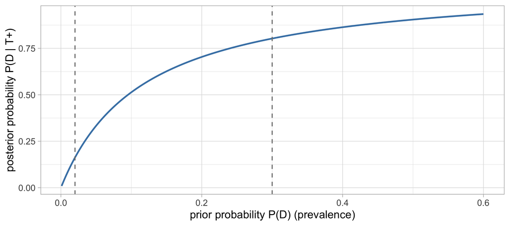

```r
sens <- 0.95; spec <- 0.90
ppv <- function(prev) sens * prev / (sens * prev + (1 - spec) * (1 - prev))

tibble(prevalence = seq(0.001, 0.6, length = 500)) |>
  mutate(ppv = ppv(prevalence)) |>
  ggplot(aes(prevalence, ppv)) +
  geom_line(linewidth = 1, colour = "steelblue") +
  geom_vline(xintercept = c(0.02, 0.30), linetype = 2, colour = "grey50") +
  labs(x = "prior probability P(D) (prevalence)",
       y = "posterior probability P(D | T+)")
```

```r
ppv(c(0.02, 0.30))
```

```
[1] 0.1623932 0.8028169
```

In a low-transmission setting (2% prevalence) a positive result gives only a 16% probability of malaria; in a high-transmission setting (30%) it gives 80%. Same test, same data, different prior, different conclusion. This is Bayesian inference in miniature:

$$\underbrace{P(D\mid T)}_{\text{posterior}} \;\propto\; \underbrace{P(T\mid D)}_{\text{likelihood}}\times\underbrace{P(D)}_{\text{prior}}.$$

The denominator $P(T)$ does not depend on the hypothesis; it just makes the posterior probabilities add up to 1.

## 3.3 From hypotheses to parameters

Usually the “hypotheses” are the possible values of a parameter $\theta$, and the “evidence” is a dataset $\mathbf{y}$. Bayes’ rule for densities is

$$p(\theta\mid\mathbf{y})=\frac{p(\mathbf{y}\mid\theta)\,p(\theta)}{p(\mathbf{y})},
\qquad p(\mathbf{y})=\int p(\mathbf{y}\mid\theta)\,p(\theta)\,d\theta,$$

and since $p(\mathbf{y})$ is a constant once the data are observed,

$$\boxed{\;p(\theta\mid\mathbf{y})\;\propto\;p(\mathbf{y}\mid\theta)\,p(\theta)\;}
\qquad\text{posterior}\propto\text{likelihood}\times\text{prior}.$$

Everything in this course follows from this line. The ingredients are:

- the **sampling model** $p(\mathbf{y}\mid\theta)$: how data are generated if we knew $\theta$. Viewed as a function of $\theta$ for fixed data it is the **likelihood**, the same object you use in GLMs;
- the **prior** $p(\theta)$: what we know about $\theta$ before seeing these data;
- the **posterior** $p(\theta\mid\mathbf{y})$: what we know after seeing the data;
- the **marginal likelihood** or **evidence** $p(\mathbf{y})$: the normalising constant. It is usually the hard part to compute, and most computational methods in this course are designed to *avoid* computing it.

## 3.4 A first computational method: grid approximation

**Example.** A district health team wants to estimate the prevalence $\pi$ of malaria parasitaemia among under-fives in a village. They test $n=30$ children and find $k=9$ positive. A survey two years ago in a neighbouring village suggested prevalence around 20-30%.

- Sampling model: $Y\mid\pi\sim\text{Bin}(n=30,\pi)$.
- Prior: $\pi\sim\text{Beta}(2,5)$, which has mean $2/7\approx0.29$ and is fairly wide.

The binomial model treats the 30 children’s results as independent given a single common prevalence $\pi$. Behind this is the judgement that, before testing, nothing distinguishes one child from another: the children are *exchangeable*. Lecture 5 shows why this judgement justifies the whole “independent given a parameter, plus a prior” set-up, and what to do when it fails.

We do not need any integration to find the posterior. We can evaluate $\text{likelihood}\times\text{prior}$ on a fine grid of values for $\pi$ and normalise numerically:

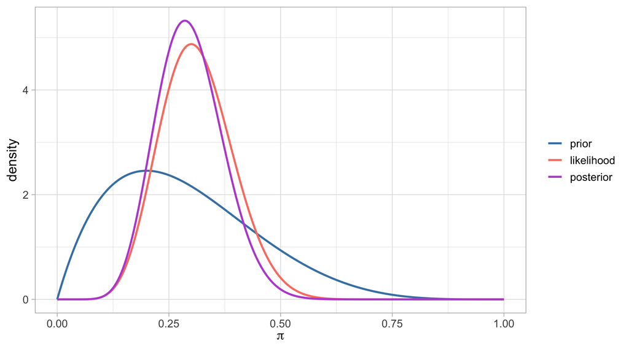

```r
n <- 30; k <- 9
a <- 2; b <- 5

grid <- tibble(pi = seq(0, 1, length = 1001)) |>
  mutate(prior      = dbeta(pi, a, b),
         likelihood = dbinom(k, size = n, prob = pi),
         unnorm     = likelihood * prior,
         posterior  = unnorm / sum(unnorm * 0.001))   # 0.001 = grid spacing

grid |>
  mutate(likelihood = likelihood / sum(likelihood * 0.001)) |>  # scaled for plotting only
  pivot_longer(c(prior, likelihood, posterior), names_to = "curve") |>
  mutate(curve = factor(curve, levels = c("prior", "likelihood", "posterior"))) |>
  ggplot(aes(pi, value, colour = curve)) +
  geom_line(linewidth = 1) +
  scale_colour_manual(values = c("steelblue", "salmon", "mediumorchid")) +
  labs(x = expression(pi), y = "density", colour = NULL)
```

The posterior is a compromise between prior and likelihood, and it is narrower than either: combining two sources of information reduces uncertainty.

**TipComputational tip: work on the log scale**

With many observations, $p(\mathbf{y}\mid\theta)$ is a product of many small numbers and underflows to 0 on a computer. Work instead with $\ell(\theta)=\log p(\mathbf{y}\mid\theta)+\log p(\theta)$. To get from $\ell$ back to a normalised posterior on a grid $\theta_1,\ldots,\theta_G$ with spacing $h$, take two steps:

1. **Stabilise:** subtract the maximum, $\ell(\theta_g)-m$ with $m=\max_g\ell(\theta_g)$, and then exponentiate. The largest value becomes $e^0=1$, so nothing underflows where the posterior has mass.
2. **Normalise:** divide by $\sum_g e^{\ell(\theta_g)-m}\,h$.

Subtracting the maximum is only a numerical device, not the normalisation. On the log scale any constant can be subtracted: it becomes a multiplicative constant after exponentiating, and step 2 removes it. The “ideal” constant to subtract would be $\log p(\mathbf y)$, which would give the normalised posterior directly. But computing $\log p(\mathbf y)$ requires exponentiating $\ell$, which is exactly where underflow happens. The two steps together are the *log-sum-exp* trick, which gives $\log p(\mathbf y)\approx m+\log\sum_g e^{\ell(\theta_g)-m}\,h$ safely. MCMC software sidesteps the issue altogether: it works with $\ell$ throughout and never needs $p(\mathbf y)$ (Lecture 3).

A **discrete prior** (e.g. “the coin is one of three coins with $\pi=0.3,0.5,0.8$”) is simply a grid with very few points: exactly the same code works.

### 3.4.1 Summarising a grid posterior by sampling

Once we have the posterior on a grid, the easiest way to summarise it is to **draw samples** from it. This idea (replace a distribution by a large sample from it) is the foundation of everything in Lectures 3-5.

```r
draws <- sample(grid$pi, size = 1e5, replace = TRUE, prob = grid$posterior)

c(post_mean = mean(draws),
  post_sd   = sd(draws),
  quantile(draws, c(0.025, 0.5, 0.975)),
  P_above_0.4 = mean(draws > 0.4))
```

```
  post_mean     post_sd        2.5%         50%       97.5% P_above_0.4
 0.29719852  0.07403816  0.16400000  0.29300000  0.45200000  0.08922000
```

Posterior mean, standard deviation, median, 95% credible interval, and the probability that prevalence exceeds 40%: all from one line each, and no calculus.

## 3.5 The exact answer: conjugacy

For this particular prior/likelihood pair we can also get the posterior exactly. Keeping only factors that depend on $\pi$:

$$p(\pi\mid k)\;\propto\;\underbrace{\pi^{k}(1-\pi)^{n-k}}_{\text{likelihood}}\;\underbrace{\pi^{a-1}(1-\pi)^{b-1}}_{\text{prior}}
=\pi^{a+k-1}(1-\pi)^{b+n-k-1},$$

which we recognise as the *kernel* of a $\text{Beta}(a+k,\;b+n-k)$ density. No integral is needed: the normalising constant must be whatever makes a Beta density integrate to 1. (The full derivation including the normalising constant is in Appendix B.1.)

When prior and posterior belong to the same family, the prior is called **conjugate** for the sampling model. Check that the grid agrees with the exact result:

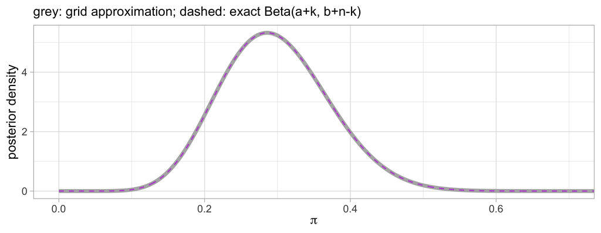

```r
ggplot(grid, aes(pi, posterior)) +
  geom_line(linewidth = 2, colour = "grey70") +
  geom_line(aes(y = dbeta(pi, a + k, b + n - k)), colour = "mediumorchid", linetype = 2) +
  coord_cartesian(xlim = c(0, 0.7)) +
  labs(x = expression(pi), y = "posterior density",
       subtitle = "grey: grid approximation; dashed: exact Beta(a+k, b+n-k)")
```

The posterior mean is a weighted average of the prior mean and the sample proportion:

$$E[\pi\mid k]=\frac{a+k}{a+b+n}=\underbrace{\frac{a+b}{a+b+n}}_{\text{weight on prior}}\cdot\frac{a}{a+b}+\underbrace{\frac{n}{a+b+n}}_{\text{weight on data}}\cdot\frac{k}{n}.$$

So $a+b$ behaves like a **prior sample size**: the Beta(2,5) prior carries the information of about 7 children, the data carry 30.

## 3.6 Prior versus data

What happens as data accumulate? Keep the observed proportion at 30% and increase $n$:

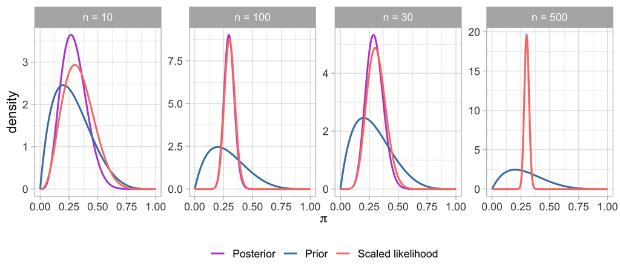

```r
post_curves <- expand_grid(n = c(10, 30, 100, 500), pi = seq(0, 1, length = 500)) |>
  mutate(k = 0.3 * n,
         Prior = dbeta(pi, a, b),
         Posterior = dbeta(pi, a + k, b + n - k),
         `Scaled likelihood` = dbeta(pi, k + 1, n - k + 1)) |>
  pivot_longer(c(Prior, Posterior, `Scaled likelihood`), names_to = "curve")

ggplot(post_curves, aes(pi, value, colour = curve)) +
  geom_line(linewidth = 0.9) +
  facet_wrap(~ paste("n =", n), nrow = 1, scales = "free_y") +
  scale_colour_manual(values = c("mediumorchid", "steelblue", "salmon")) +
  labs(x = expression(pi), y = "density", colour = NULL) +
  theme(legend.position = "bottom")
```

With more data the posterior concentrates and the likelihood dominates: different reasonable priors lead to practically the same conclusions. One exception: **if the prior gives zero probability to a region, so does the posterior, no matter how much data we collect** (because posterior $\propto$ likelihood $\times$ 0). Never put zero prior probability on values that are physically possible.

## 3.7 Sequential updating

Today’s posterior is tomorrow’s prior. If the team tests another 20 children and finds 4 positive, then starting from the $\text{Beta}(11,26)$ posterior gives a $\text{Beta}(15,42)$ posterior, which is exactly the same as analysing all 50 children at once with the original $\text{Beta}(2,5)$ prior. Bayesian inference is coherent in this sense.

## 3.8 Why grids are not enough

The grid method needs the posterior evaluated at every grid point. With 100 grid points per parameter:

| Parameters | Grid points |
| --- | --- |
| 1 | 100 |
| 2 | 10,000 |
| 5 | 10<sup>10</sup> |
| 10 | 10<sup>20</sup> |

A logistic regression with 10 covariates is already out of reach. This **curse of dimensionality** motivates Monte Carlo and MCMC (Lecture 3), which spend computational effort only where the posterior has appreciable mass.

**NotePractical 1**

Bayes’ rule for diagnostic tests (combining two tests); grid approximation for a binomial and a Poisson model; checking grid results against conjugate formulae; effect of prior and sample size.

# 4 Lecture 2: Priors, conjugate models and posterior summaries

## 4.1 A catalogue of conjugate models

Conjugate models give posterior distributions in closed form. They are useful for quick calculations, as building blocks inside Gibbs samplers (Lecture 3), and for checking software. You should know what they are and how to use them; the derivations are in Appendix B.

| Sampling model | Conjugate prior | Posterior | Interpretation of prior parameters |
| --- | --- | --- | --- |
| $Y\sim\text{Bin}(n,\pi)$ | $\pi\sim\text{Beta}(a,b)$ | $\text{Beta}(a+k,\;b+n-k)$ | $a$ prior successes, $b$ prior failures |
| $Y_i\sim\text{Pois}(\lambda)$ | $\lambda\sim\text{Gamma}(a,b)$ | $\text{Gamma}(a+\sum y_i,\;b+n)$ | $a$ prior total count in $b$ prior observations |
| $Y_i\sim\text{Exp}(\lambda)$ | $\lambda\sim\text{Gamma}(a,b)$ | $\text{Gamma}(a+n,\;b+\sum y_i)$ | $a$ prior events in total time $b$ |
| $Y_i\sim\mathcal N(\mu,\sigma^2)$, $\sigma^2$ known | $\mu\sim\mathcal N(\mu_0,\tau_0^2)$ | $\mathcal N(\mu_n,\tau_n^2)$, see below | $\mu_0$ prior guess, $\tau_0^2$ its uncertainty |
| $Y_i\sim\mathcal N(\mu,1/\phi)$, $\mu$ known | precision $\phi\sim\text{Gamma}(a,b)$ | $\text{Gamma}\left(a+\tfrac n2,\;b+\tfrac12\sum(y_i-\mu)^2\right)$ |  |
| $\mathbf Y\sim\text{Multinom}(n,\mathbf p)$ | $\mathbf p\sim\text{Dirichlet}(\boldsymbol\alpha)$ | $\text{Dirichlet}(\boldsymbol\alpha+\mathbf y)$ | $\alpha_j$ prior counts in category $j$ |

For the normal mean with known variance:

$$\frac{1}{\tau_n^2}=\frac{1}{\tau_0^2}+\frac{n}{\sigma^2},\qquad
\mu_n=\tau_n^2\left(\frac{\mu_0}{\tau_0^2}+\frac{n\bar y}{\sigma^2}\right).$$

*Posterior precision = prior precision + data precision; posterior mean = precision-weighted average of prior mean and sample mean.* This pattern (weights proportional to amount of information) appears in every row of the table.

### 4.1.1 Example: Gamma-Poisson

The number of malaria episodes recorded for 18 children over one rainy season:

```r
y <- c(1, 3, 2, 3, 0, 2, 6, 4, 4, 1, 1, 3, 2, 3, 1, 1, 3, 0)
c(n = length(y), sum = sum(y), mean = mean(y))
```

```
        n       sum      mean
18.000000 40.000000  2.222222
```

With $Y_i\mid\lambda\sim_{\text{iid}}\text{Pois}(\lambda)$ and prior $\lambda\sim\text{Gamma}(a,b)$:

$$p(\lambda\mid\mathbf y)\propto\underbrace{\lambda^{\sum y_i}e^{-n\lambda}}_{\text{likelihood}}\;\underbrace{\lambda^{a-1}e^{-b\lambda}}_{\text{prior}}
=\lambda^{a+\sum y_i-1}e^{-(b+n)\lambda}\;\Rightarrow\;\lambda\mid\mathbf y\sim\text{Gamma}\left(a+\textstyle\sum y_i,\;b+n\right).$$

Note that the data enter only through $n$ and $\sum y_i$ (a **sufficient statistic**). With a $\text{Gamma}(5,2)$ prior (prior mean 2.5 episodes, worth about 2 children’s data), the posterior is $\text{Gamma}(45, 20)$.

## 4.2 Choosing a prior

There is no single “correct” prior. There are, however, good and bad ways of choosing one, and the choice should always be **stated, justified and checked**.

### 4.2.1 Types of prior

- **Informative priors** encode substantive knowledge: a previous study, a meta-analysis, a biological constraint, expert opinion. A convenient way to build one: choose a prior mean $m$ and an equivalent prior sample size $n_0$, then e.g. for a proportion use $\text{Beta}(m n_0,\,(1-m)n_0)$. Opinions from several experts can be pooled as a mixture of their priors.
- **Weakly informative priors** rule out implausible values without imposing a specific guess, e.g. a log-odds ratio of 10 (odds ratio $\approx$ 22,000) is not plausible for most exposures, so $\mathcal N(0,1.5^2)$ on a log-odds ratio is a sensible default. These are the recommended defaults for most regression parameters.
- **Vague / “non-informative” / reference priors** try to let the data speak. Examples are uniform priors and **Jeffreys priors** $p_J(\theta)\propto\sqrt{I(\theta)}$, where $I(\theta)$ is the Fisher information (Appendix B.3). Jeffreys priors are invariant to reparameterisation; for the binomial the Jeffreys prior is $\text{Beta}(\tfrac12,\tfrac12)$, for the Poisson it is $p(\lambda)\propto\lambda^{-1/2}$, which is **improper** (does not integrate to 1). Improper priors can be used only if the resulting posterior is proper, which must be checked.

**WarningA flat prior is not an uninformative prior**

A prior that is flat on one scale is not flat on another. A uniform prior on a prevalence $\pi$ implies a far-from-flat prior on the log-odds $\text{logit}(\pi)$. Conversely, the very common “vague” prior $\mathcal N(0,100^2)$ on a log-odds puts about 90% of its mass on prevalences below 0.001% or above 99.999%:

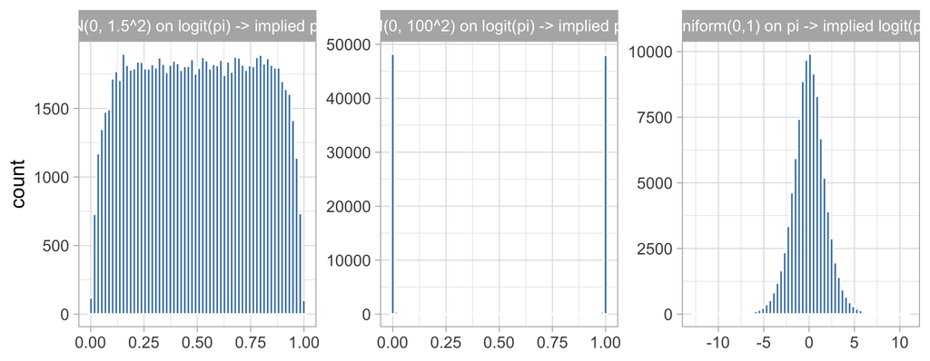

```r
tibble(`Uniform(0,1) on pi -> implied logit(pi)` = qlogis(runif(1e5)),
       `N(0, 100^2) on logit(pi) -> implied pi` = plogis(rnorm(1e5, 0, 100)),
       `N(0, 1.5^2) on logit(pi) -> implied pi` = plogis(rnorm(1e5, 0, 1.5))) |>
  pivot_longer(everything()) |>
  ggplot(aes(value)) +
  geom_histogram(bins = 60, fill = "steelblue", colour = "white") +
  facet_wrap(~name, scales = "free") +
  labs(x = NULL, y = "count")
```

The lesson: **think about priors on the scale of quantities you understand**, which is almost always the scale of the data, not the scale of the parameter.

### 4.2.2 Prior predictive checks

The practical way to do this is to simulate data from the prior, before looking at the real data:

$$\theta^{(s)}\sim p(\theta),\qquad \tilde{\mathbf y}^{(s)}\sim p(\mathbf y\mid\theta^{(s)}),\qquad s=1,\ldots,S.$$

The $\tilde{\mathbf y}^{(s)}$ are draws from the **prior predictive distribution** $p(\tilde{\mathbf y})=\int p(\tilde{\mathbf y}\mid\theta)p(\theta)d\theta$. If simulated datasets look absurd (children with 40 malaria episodes per season), the prior is too vague or wrong.

```r
S <- 5000
prior_pred <- tibble(
  prior = rep(c("Gamma(5, 2)", "Gamma(0.01, 0.01)"), each = S),
  lambda = c(rgamma(S, 5, 2), rgamma(S, 0.01, 0.01))) |>
  mutate(y_tilde = rpois(n(), lambda))

prior_pred |>
  group_by(prior) |>
  summarise(`P(y > 15)` = mean(y_tilde > 15),
            `P(y = 0)`  = mean(y_tilde == 0),
            `99.9% quantile` = quantile(y_tilde, 0.999))
```

```
# A tibble: 2 × 4
  prior             `P(y > 15)` `P(y = 0)` `99.9% quantile`
  <chr>                   <dbl>      <dbl>            <dbl>
1 Gamma(0.01, 0.01)      0.0146      0.952             97.0
2 Gamma(5, 2)            0           0.129             11
```

### 4.2.3 Prior sensitivity analysis

When in doubt, fit the model under several reasonable priors and report whether conclusions change. For the prevalence example of Lecture 1:

```r
priors <- tribble(
  ~prior,                          ~a,   ~b,
  "Uniform Beta(1,1)",              1,    1,
  "Jeffreys Beta(0.5,0.5)",       0.5,  0.5,
  "Weakly informative Beta(2,5)",   2,    5,
  "Strong, sceptical Beta(10,40)", 10,   40)

priors |>
  mutate(post_mean = (a + k) / (a + b + n),
         lower = qbeta(0.025, a + k, b + n - k),
         upper = qbeta(0.975, a + k, b + n - k),
         `P(pi > 0.2)` = 1 - pbeta(0.2, a + k, b + n - k)) |>
  kable(digits = 3)
```

| prior | a | b | post_mean | lower | upper | P(pi > 0.2) |
| --- | --- | --- | --- | --- | --- | --- |
| Uniform Beta(1,1) | 1.0 | 1.0 | 0.312 | 0.167 | 0.480 | 0.925 |
| Jeffreys Beta(0.5,0.5) | 0.5 | 0.5 | 0.306 | 0.160 | 0.477 | 0.910 |
| Weakly informative Beta(2,5) | 2.0 | 5.0 | 0.297 | 0.163 | 0.452 | 0.911 |
| Strong, sceptical Beta(10,40) | 10.0 | 40.0 | 0.238 | 0.151 | 0.336 | 0.780 |

The first three priors give almost identical conclusions; the strong prior (worth 50 children, centred on 20%) pulls the estimate down noticeably. That is not wrong, but it must be reported and justified.

## 4.3 Summarising the posterior

The posterior *is* the answer. For communication we summarise it.

### 4.3.1 Point estimates

A point estimate can be justified as the value minimising the **posterior expected loss** $\int L(\theta,\hat\theta)\,p(\theta\mid y)\,d\theta$ (details in Appendix C):

| Loss $L(\theta,\hat\theta)$ | Optimal estimate |
| --- | --- |
| Squared error $(\theta-\hat\theta)^2$ | Posterior mean |
| Absolute error $\lvert\theta-\hat\theta\rvert$ | Posterior median |
| 0-1 loss, $1$ if $\lvert\theta-\hat\theta\rvert\geq\epsilon$ and 0 otherwise, $\epsilon\to0$ | Posterior mode (MAP) |

For skewed posteriors (variances, rates, odds ratios) the median is usually the most sensible single number. The MAP depends on the parameterisation and is not recommended as a default.

### 4.3.2 Credible intervals

A $100(1-\alpha)\%$ **credible interval** $[l,u]$ satisfies $P(l\leq\theta\leq u\mid\mathbf y)=1-\alpha$. Two common choices:

- **Equal-tailed (quantile-based)** interval: $\alpha/2$ posterior probability in each tail. Invariant to monotone transformations (the interval for $e^\theta$ is the exponential of the interval for $\theta$).
- **Highest posterior density (HPD)** interval: the narrowest region with the required probability; every point inside has higher density than every point outside. May be a union of intervals for multimodal posteriors. Not transformation-invariant.

```r
post_a <- 5 + sum(y); post_b <- 2 + length(y)   # Gamma(45, 20) posterior

rbind(equal_tailed = qgamma(c(0.025, 0.975), post_a, post_b),
      HPD          = hdi(qgamma, 0.95, shape = post_a, rate = post_b))
```

```
                lower    upper
equal_tailed 1.641165 2.953397
HPD          1.611342 2.917067
```

Interpretation: *given the model, prior and data, there is a 95% probability that the mean number of episodes per child lies in this interval.* This is the statement people often (wrongly) attach to a frequentist confidence interval. Under a vague prior, the two intervals are frequently numerically close; their interpretations are not the same.

### 4.3.3 Posterior probabilities of clinically relevant events

Often more useful than any interval: $P(\lambda>3\mid\mathbf y)$, $P(\text{OR}<1\mid\mathbf y)$, $P(\text{risk difference}>5\%\mid\mathbf y)$. These answer the questions decision-makers actually ask.

```r
c(`P(lambda > 3 | y)` = 1 - pgamma(3, post_a, post_b),
  `P(lambda < 2 | y)` = pgamma(2, post_a, post_b))
```

```
P(lambda > 3 | y) P(lambda < 2 | y)
        0.0189731         0.2343151
```

### 4.3.4 Bayes factors (brief)

For two hypotheses or models $H_1,H_2$:

$$\underbrace{\frac{P(H_1\mid\mathbf y)}{P(H_2\mid\mathbf y)}}_{\text{posterior odds}}
=\underbrace{\frac{p(\mathbf y\mid H_1)}{p(\mathbf y\mid H_2)}}_{\text{Bayes factor }BF_{12}}\times
\underbrace{\frac{P(H_1)}{P(H_2)}}_{\text{prior odds}}.$$

The Bayes factor is a ratio of *marginal likelihoods* $p(\mathbf y\mid H)=\int p(\mathbf y\mid\theta,H)p(\theta\mid H)d\theta$. For composite hypotheses it can be extremely sensitive to the prior (a vaguer prior under $H_1$ always favours $H_2$), and it is hard to compute for realistic models. For **model comparison** we will prefer predictive criteria (LOO, WAIC; Lecture 5). For **questions about parameters**, report posterior probabilities directly.

## 4.4 Prediction

The **posterior predictive distribution** for a new observation $\tilde y$ averages the sampling model over posterior uncertainty in $\theta$:

$$p(\tilde y\mid\mathbf y)=\int p(\tilde y\mid\theta)\,p(\theta\mid\mathbf y)\,d\theta.$$

It is wider than $p(\tilde y\mid\hat\theta)$ because it accounts for *both* the randomness of new data *and* our uncertainty about $\theta$. Plugging in a point estimate $\hat\theta$ ignores the second source and gives over-confident predictions.

For the Gamma-Poisson model the integral can be done analytically: $\tilde Y\mid\mathbf y\sim\text{NegBin}\left(a+\sum y_i,\;\frac{b+n}{b+n+1}\right)$ (Appendix B.2). But the integral has a much simpler *simulation* form, which works for **every** model:

$$\theta^{(s)}\sim p(\theta\mid\mathbf y),\qquad\tilde y^{(s)}\sim p(\tilde y\mid\theta^{(s)}).$$

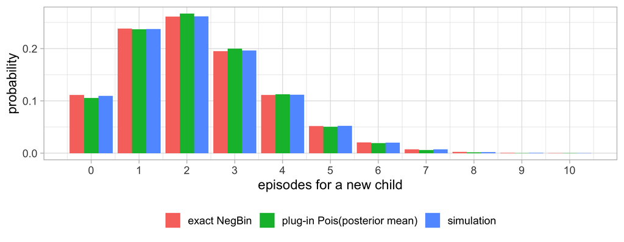

```r
S <- 1e5
lambda_s <- rgamma(S, post_a, post_b)          # 1. draw parameters from the posterior
y_tilde  <- rpois(S, lambda_s)                 # 2. draw new data given each parameter

tibble(k = 0:10) |>
  mutate(`simulation` = map_dbl(k, ~ mean(y_tilde == .x)),
         `exact NegBin` = dnbinom(k, size = post_a, prob = post_b / (post_b + 1)),
         `plug-in Pois(posterior mean)` = dpois(k, post_a / post_b)) |>
  pivot_longer(-k) |>
  ggplot(aes(k, value, fill = name)) +
  geom_col(position = "dodge") +
  scale_x_continuous(breaks = 0:10) +
  labs(x = "episodes for a new child", y = "probability", fill = NULL) +
  theme(legend.position = "bottom")
```

Simulation and exact answer agree; the plug-in Poisson is slightly too narrow. Two lines of code replaced a page of algebra.

## 4.5 Where closed forms run out: the normal model with unknown mean *and* variance

For $Y_i\sim\mathcal N(\mu,\sigma^2)$ with both parameters unknown, a fully conjugate prior exists (the normal-inverse-gamma, Appendix B.4), but it forces the prior uncertainty about $\mu$ to be proportional to $\sigma^2$, which is often unnatural. The more natural choice is an **independent** (semi-conjugate) prior

$$\mu\sim\mathcal N(\mu_0,\tau_0^2),\qquad 1/\sigma^2\sim\text{Gamma}\left(\tfrac{\nu_0}{2},\tfrac{\nu_0\sigma_0^2}{2}\right),$$

for which the joint posterior $p(\mu,\sigma^2\mid\mathbf y)$ is **not** a standard distribution. However, each *full conditional* distribution is standard:

$$\mu\mid\sigma^2,\mathbf y\sim\mathcal N(\mu_n,\tau_n^2),\qquad
1/\sigma^2\mid\mu,\mathbf y\sim\text{Gamma}\left(\frac{\nu_0+n}{2},\;\frac{\nu_0\sigma_0^2+\sum_i(y_i-\mu)^2}{2}\right),$$

with $\mu_n,\tau_n^2$ as in the table above. This is exactly the situation the Gibbs sampler (Lecture 3) is designed for. Almost every realistic model (regression with non-normal outcomes, random effects, missing data) is in this situation or worse, which is why the rest of the course is about computation.

**NotePractical 2**

Using conjugate results for a two-group comparison (number of children per woman, GSS data); prior predictive checks; prior sensitivity analysis; point and interval summaries (equal-tailed and HPD); posterior predictive distributions by simulation, compared with the exact negative binomial.

# 5 Lecture 3: Monte Carlo and Markov chain Monte Carlo

## 5.1 Monte Carlo integration

Almost every posterior quantity we care about is an expectation:

$$E[g(\theta)\mid\mathbf y]=\int g(\theta)\,p(\theta\mid\mathbf y)\,d\theta.$$

Mean ($g(\theta)=\theta$), variance, probabilities ($g(\theta)=I(\theta\in A)$), and predictive probabilities are all of this form. If we can draw $\theta^{(1)},\ldots,\theta^{(S)}\sim_{\text{iid}}p(\theta\mid\mathbf y)$, then by the **law of large numbers**

$$\bar g_S=\frac1S\sum_{s=1}^S g(\theta^{(s)})\;\longrightarrow\;E[g(\theta)\mid\mathbf y]\quad\text{as }S\to\infty,$$

and by the **central limit theorem** the error is approximately normal with

$$\text{MCSE}(\bar g_S)=\frac{\text{sd}(g(\theta))}{\sqrt S}.$$

The **Monte Carlo standard error** (MCSE) tells us how many digits of a simulation result we can trust. It shrinks like $1/\sqrt S$, *independently of the dimension of $\theta$*: this is why simulation beats grids.

**Important**

Keep two kinds of uncertainty apart. The **posterior SD** describes uncertainty about $\theta$ and does not shrink as we simulate more. The **MCSE** describes numerical error in our summary and goes to 0 as $S\to\infty$. Report posterior summaries; make sure the MCSE is small enough not to matter.

### 5.1.1 Example: comparing two groups

In the General Social Survey (Practical 2), the numbers of children of 40-year-old women without / with a college degree gave posteriors $\theta_1\mid\mathbf y\sim\text{Gamma}(219,112)$ and $\theta_2\mid\mathbf y\sim\text{Gamma}(68,45)$. Questions about *functions* of several parameters, which would need double integrals, become one-liners:

```r
S <- 1e5
theta1 <- rgamma(S, 219, 112)
theta2 <- rgamma(S, 68, 45)

prob  <- mean(theta1 > theta2)
ratio <- theta1 / theta2

c(`P(theta1 > theta2)` = prob,
  MCSE = sqrt(prob * (1 - prob) / S),
  `median rate ratio` = median(ratio),
  quantile(ratio, c(0.025, 0.975)))
```

```
P(theta1 > theta2)               MCSE  median rate ratio               2.5%
       0.973740000        0.000505672        1.298359083        0.997045199
             97.5%
       1.714282977
```

Once we have draws, **every function of the parameters has a posterior distribution for free**: rate ratios, risk differences, numbers needed to treat, predicted probabilities, rankings. Just compute the function for each draw.

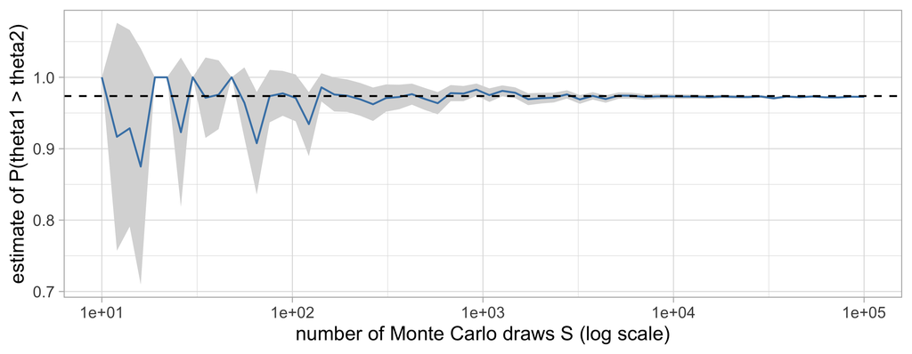

```r
tibble(S = round(10^seq(1, 5, length = 60))) |>
  mutate(estimate = map_dbl(S, ~ mean(rgamma(.x, 219, 112) > rgamma(.x, 68, 45))),
         mcse = sqrt(estimate * (1 - estimate) / S)) |>
  ggplot(aes(S, estimate)) +
  geom_ribbon(aes(ymin = estimate - 2 * mcse, ymax = estimate + 2 * mcse), fill = "grey85") +
  geom_line(colour = "steelblue") +
  geom_hline(yintercept = prob, linetype = 2) +
  scale_x_log10() +
  labs(x = "number of Monte Carlo draws S (log scale)", y = "estimate of P(theta1 > theta2)")
```

## 5.2 Why we need MCMC

Monte Carlo needs independent draws from the posterior. We can get them when the posterior is a standard distribution, but usually all we can do is evaluate the *unnormalised* posterior

$$\tilde p(\theta\mid\mathbf y)=p(\mathbf y\mid\theta)\,p(\theta),$$

pointwise, because the normalising constant $p(\mathbf y)$ is an intractable integral.

**Markov chain Monte Carlo** constructs a sequence $\theta^{(1)},\theta^{(2)},\ldots$ in which each value depends only on the previous one (a **Markov chain**), designed so that its long-run distribution (its **stationary distribution**) is the posterior. The price: the draws are *dependent* and the chain needs time to reach the posterior from its starting point. The payoff: we only ever need $\tilde p$, never $p(\mathbf y)$, since the constant cancels in ratios.

### 5.2.1 A non-conjugate example

Return to the malaria-episodes data but now put the prior on the **log rate**, which is natural if we later want to add covariates (Poisson regression):

$$Y_i\mid\lambda\sim_{\text{iid}}\text{Pois}(\lambda),\qquad \lambda=e^{\theta},\qquad \theta\sim\mathcal N(0,1.5^2).$$

This prior is not conjugate; the posterior of $\theta$ has no standard form. But its log is trivial to evaluate:

```r
log_post <- function(theta) {
  sum(dpois(y, lambda = exp(theta), log = TRUE)) + dnorm(theta, 0, 1.5, log = TRUE)
}
```

For reference (and only because this is one-dimensional) we can also compute a grid answer:

```r
theta_grid <- seq(-1, 2, length = 2001)
lp <- sapply(theta_grid, log_post)
grid_post <- exp(lp - max(lp)); grid_post <- grid_post / sum(grid_post * diff(theta_grid)[1])
```

## 5.3 The Metropolis algorithm

Starting from some $\theta^{(0)}$, repeat for $s=1,2,\ldots,S$:

1. **Propose** $\theta^*\sim\mathcal N(\theta^{(s-1)},\delta^2)$ (a random-walk step of size $\delta$).
2. Compute the **acceptance ratio** $r=\dfrac{\tilde p(\theta^*\mid\mathbf y)}{\tilde p(\theta^{(s-1)}\mid\mathbf y)}$; the unknown $p(\mathbf y)$ cancels.
3. Draw $u\sim\text{Unif}(0,1)$. If $u<r$ **accept**, $\theta^{(s)}=\theta^*$; otherwise **reject**, $\theta^{(s)}=\theta^{(s-1)}$.

Moves uphill (towards higher posterior density) are always accepted; moves downhill are accepted with probability $r$. The chain therefore spends time in each region in proportion to its posterior probability. On the log scale step 3 becomes: accept if $\log u<\log\tilde p(\theta^*)-\log\tilde p(\theta^{(s-1)})$.

```r
metropolis <- function(log_target, n_iter, init, step) {
  theta <- numeric(n_iter)
  theta[1] <- init
  lp_current <- log_target(init)
  n_accept <- 0
  for (s in 2:n_iter) {
    proposal <- rnorm(1, mean = theta[s - 1], sd = step)
    lp_proposal <- log_target(proposal)
    if (log(runif(1)) < lp_proposal - lp_current) {
      theta[s] <- proposal; lp_current <- lp_proposal; n_accept <- n_accept + 1
    } else {
      theta[s] <- theta[s - 1]
    }
  }
  list(theta = theta, acceptance_rate = n_accept / (n_iter - 1))
}

set.seed(1)
run <- metropolis(log_post, n_iter = 20000, init = -1, step = 0.3)
run$acceptance_rate
```

```
[1] 0.5134257
```

That is the whole algorithm: fifteen lines of `R`. Does it work?

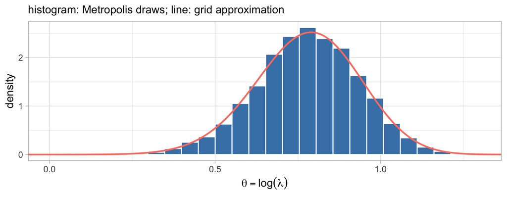

```r
keep <- run$theta[-(1:1000)]      # discard the first 1000 iterations (burn-in)

ggplot() +
  geom_histogram(aes(x = keep, y = after_stat(density)), bins = 60,
                 fill = "steelblue", colour = "white") +
  geom_line(aes(theta_grid, grid_post), colour = "salmon", linewidth = 1) +
  coord_cartesian(xlim = c(0, 1.3)) +
  labs(x = expression(theta == log(lambda)), y = "density",
       subtitle = "histogram: Metropolis draws; line: grid approximation")
```

```r
c(post_mean_lambda = mean(exp(keep)), quantile(exp(keep), c(0.025, 0.975)))
```

```
post_mean_lambda             2.5%            97.5%
        2.204286         1.576547         2.911583
```

### 5.3.1 Tuning the step size

The algorithm is correct for *any* step size $\delta>0$, but its **efficiency** depends strongly on $\delta$:

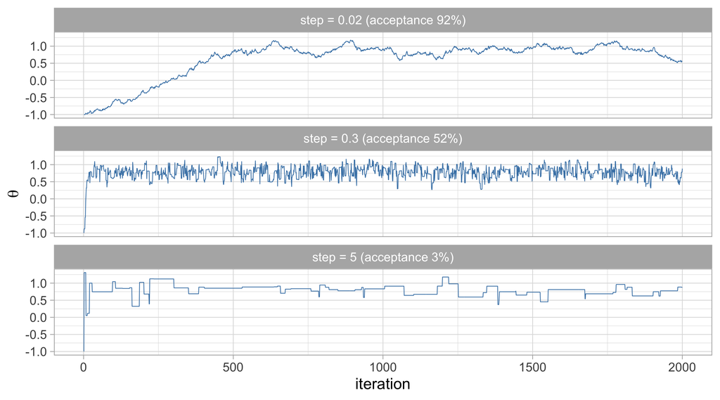

```r
set.seed(2)
runs <- map_dfr(c(0.02, 0.3, 5), function(d) {
  r <- metropolis(log_post, n_iter = 2000, init = -1, step = d)
  tibble(step = paste0("step = ", d, " (acceptance ", round(100 * r$acceptance_rate), "%)"),
         iteration = seq_along(r$theta), theta = r$theta)
})

ggplot(runs, aes(iteration, theta)) +
  geom_line(colour = "steelblue", linewidth = 0.3) +
  facet_wrap(~step, ncol = 1) +
  labs(y = expression(theta))
```

- **Too small**: nearly every proposal is accepted but the chain crawls; it takes hundreds of iterations to leave the (bad) starting value and successive draws are almost identical.
- **Too large**: most proposals land in the tails and are rejected; the chain sticks for long stretches.
- **About right**: the trace looks like a “hairy caterpillar”. For random-walk Metropolis, acceptance rates of roughly 20-50% are a good target (about 44% in one dimension, decreasing towards 23% in many dimensions).

Software such as `NIMBLE` tunes $\delta$ automatically during an adaptation phase.

### 5.3.2 Metropolis-Hastings

If the proposal distribution $q(\theta^*\mid\theta)$ is not symmetric (for example, proposals on the log scale for a positive parameter), the ratio needs a correction:

$$r=\frac{\tilde p(\theta^*\mid\mathbf y)\,q(\theta^{(s-1)}\mid\theta^*)}{\tilde p(\theta^{(s-1)}\mid\mathbf y)\,q(\theta^*\mid\theta^{(s-1)})}.$$

This is the **Metropolis-Hastings** algorithm. For a symmetric proposal the $q$ terms cancel and we recover Metropolis. The correction ensures *detailed balance*, $p(\theta)T(\theta\to\theta^*)=p(\theta^*)T(\theta^*\to\theta)$, which guarantees that the posterior is the stationary distribution of the chain.

## 5.4 The Gibbs sampler

When the parameter is a vector $\boldsymbol\phi=(\phi_1,\ldots,\phi_p)$ and every **full conditional** $p(\phi_j\mid\text{all other parameters},\mathbf y)$ is a distribution we can sample from, update one component at a time, **always conditioning on the most recent values**:

$$\begin{aligned}
\phi_1^{(s)}&\sim p\left(\phi_1\mid\phi_2^{(s-1)},\phi_3^{(s-1)},\ldots,\phi_p^{(s-1)},\mathbf y\right)\\
\phi_2^{(s)}&\sim p\left(\phi_2\mid\phi_1^{(s)},\phi_3^{(s-1)},\ldots,\phi_p^{(s-1)},\mathbf y\right)\\
&\;\;\vdots\\
\phi_p^{(s)}&\sim p\left(\phi_p\mid\phi_1^{(s)},\phi_2^{(s)},\ldots,\phi_{p-1}^{(s)},\mathbf y\right)
\end{aligned}$$

Gibbs sampling is a special case of Metropolis-Hastings in which the proposal is the full conditional itself, and every proposal is accepted ($r=1$).

### 5.4.1 Example: haemoglobin with unknown mean and variance

Haemoglobin (g/dL) measured in 20 pregnant women at an antenatal clinic (simulated data):

```r
set.seed(42)
hb <- round(rnorm(20, mean = 10.8, sd = 1.4), 1)
n_hb <- length(hb); ybar <- mean(hb)
c(n = n_hb, mean = ybar, sd = sd(hb))
```

```
        n      mean        sd
20.000000 11.070000  1.824425
```

Semi-conjugate priors from Lecture 2: $\mu\sim\mathcal N(12,2^2)$ and $1/\sigma^2\sim\text{Gamma}(\nu_0/2,\nu_0\sigma_0^2/2)$ with $\nu_0=1$, $\sigma_0=1.5$. The Gibbs sampler alternates between the two full conditionals:

```r
gibbs_normal <- function(y, S, mu_init, sigma2_init,
                         mu0 = 12, tau0_2 = 4, nu0 = 1, sigma0_2 = 1.5^2) {
  n <- length(y); ybar <- mean(y)
  mu <- sigma2 <- numeric(S)
  mu[1] <- mu_init; sigma2[1] <- sigma2_init
  for (s in 2:S) {
    # 1. mu | sigma2, y  ~ Normal
    tau_n2 <- 1 / (1 / tau0_2 + n / sigma2[s - 1])
    mu_n   <- tau_n2 * (mu0 / tau0_2 + n * ybar / sigma2[s - 1])
    mu[s]  <- rnorm(1, mu_n, sqrt(tau_n2))
    # 2. 1/sigma2 | mu, y ~ Gamma   (uses the NEW value mu[s])
    shape <- (nu0 + n) / 2
    rate  <- (nu0 * sigma0_2 + sum((y - mu[s])^2)) / 2
    sigma2[s] <- 1 / rgamma(1, shape = shape, rate = rate)
  }
  tibble(iteration = 1:S, mu = mu, sigma = sqrt(sigma2))
}

set.seed(3)
gs <- gibbs_normal(hb, S = 5000, mu_init = 6, sigma2_init = 20)   # deliberately poor start
```

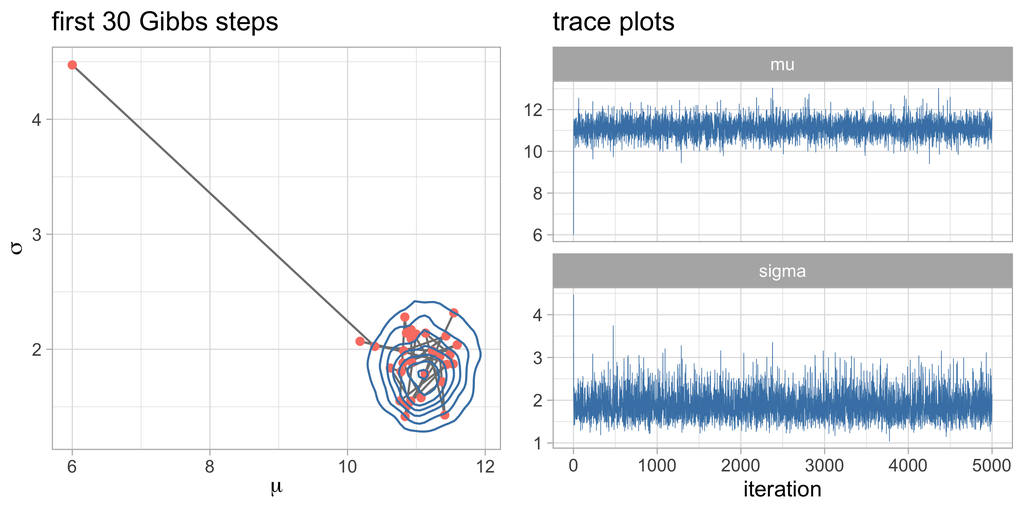

```r
p1 <- ggplot(gs[1:30, ], aes(mu, sigma)) +
  geom_path(colour = "grey50") + geom_point(colour = "salmon") +
  geom_density_2d(data = gs[-(1:500), ], colour = "steelblue") +
  labs(title = "first 30 Gibbs steps", x = expression(mu), y = expression(sigma))
p2 <- gs |> pivot_longer(c(mu, sigma)) |>
  ggplot(aes(iteration, value)) + geom_line(linewidth = 0.2, colour = "steelblue") +
  facet_wrap(~name, ncol = 1, scales = "free_y") + labs(title = "trace plots", y = NULL)
gridExtra::grid.arrange(p1, p2, ncol = 2)
```

```r
gs[-(1:500), ] |>
  summarise(across(c(mu, sigma), list(mean = mean, lo = ~quantile(.x, 0.025), hi = ~quantile(.x, 0.975))))
```

```
# A tibble: 1 × 6
  mu_mean mu_lo mu_hi sigma_mean sigma_lo sigma_hi
    <dbl> <dbl> <dbl>      <dbl>    <dbl>    <dbl>
1    11.1  10.3  11.9       1.88     1.37     2.64
```

## 5.5 Beyond Metropolis and Gibbs

Real software combines and extends these building blocks:

- **Metropolis-within-Gibbs**: update each parameter (or block of parameters) in turn, by a Gibbs step if its full conditional is standard, by a Metropolis step otherwise. This is essentially what `NIMBLE` and `JAGS` do by default.
- **Block updating**: update strongly correlated parameters jointly (e.g. all regression coefficients), with a multivariate random-walk or slice sampler. One-at-a-time updates move very slowly along narrow diagonal ridges.
- **Hamiltonian Monte Carlo (HMC)** and its adaptive version **NUTS** use the *gradient* of $\log\tilde p$ to propose distant moves that are still likely to be accepted. They scale much better to high dimensions and correlated posteriors. HMC/NUTS is the engine of `Stan` (and `brms`), and is available in `NIMBLE` through the `nimbleHMC` package.
- **Approximate methods** that avoid sampling altogether (integrated nested Laplace approximation, INLA; variational inference) are fast for particular model classes, at the cost of being approximations.

## 5.6 When MCMC struggles

Things to watch for (they motivate the diagnostics of Lecture 4):

- **Starting values** far from the posterior: need a longer burn-in; use several chains from dispersed starting values.
- **Strong posterior correlation** between parameters, e.g. intercept and slope when a covariate is not centred: one-at-a-time samplers mix slowly.
- **Multimodality**: a chain can get stuck in one mode; different chains may find different modes.
- **Weakly identified parameters** (vague priors + little data): the chain drifts over huge ranges.
- **“Funnels”** in hierarchical models (Lecture 5): the scale of some parameters depends strongly on another parameter.

**NotePractical 3**

Monte Carlo estimation and MCSE; posterior predictive probabilities by simulation (GSS data); writing your own Metropolis sampler for a Poisson model with a normal prior on the log rate, tuning the step size; extending it to two parameters (Poisson regression with one covariate); writing a Gibbs sampler for the normal model.

# 6 Lecture 4: MCMC in practice with NIMBLE

## 6.1 Software for Bayesian computation

| Software | Model language | Main samplers | Notes |
| --- | --- | --- | --- |
| `NIMBLE` (`R` package) | `BUGS` dialect, written inside `R` | Conjugate Gibbs, adaptive Metropolis, slice and block (e.g. `AF_slice`) samplers; HMC via `nimbleHMC` | Installs from CRAN; compiles models to C++; very flexible (custom distributions and samplers). **Used in this course.** |
| `Stan` (`rstan`, `cmdstanr`) | Own language | HMC / NUTS | State of the art for continuous parameters; excellent diagnostics; no discrete parameters. |
| `brms`, `rstanarm` | `R` formula syntax (`y ~ x + (1 \| group)`) | Stan under the hood | Fastest route from a GLMM to a Bayesian fit. |
| `JAGS` (`rjags`) | `BUGS` | Gibbs, slice, Metropolis | Very similar code to `NIMBLE`; development is now slow. |
| `R-INLA` | `R` formula syntax | Not MCMC: nested Laplace approximations | Very fast for latent Gaussian models (e.g. spatial disease mapping). |

The concepts (model specification, priors, diagnostics, checking) transfer directly between these tools. Knowing `BUGS`/`NIMBLE` code also helps you read a large body of published epidemiological models.

## 6.2 The NIMBLE workflow

A `NIMBLE` analysis has four ingredients:

1. **Model code**, written with `nimbleCode()`. It declares *stochastic* relationships with `~` and *deterministic* ones with `<-`, much like writing the model on paper.
2. **Constants** (sample sizes, covariates that are fixed) and **data** (observed stochastic nodes).
3. **Initial values** for the unknown quantities (one set per chain, ideally dispersed).
4. **MCMC settings**: which nodes to monitor, number of chains, iterations, burn-in.

### 6.2.1 Example: the non-conjugate Poisson model of Lecture 3

```r
pois_code <- nimbleCode({
  # sampling model
  for (i in 1:N) {
    y[i] ~ dpois(lambda)
  }
  lambda <- exp(theta)          # deterministic node
  # prior
  theta ~ dnorm(0, sd = 1.5)
})
```

The quickest way to run it is the one-line interface `nimbleMCMC()`:

```r
pois_fit <- nimbleMCMC(
  code      = pois_code,
  constants = list(N = length(y)),
  data      = list(y = y),
  inits     = function() list(theta = rnorm(1, 0, 1)),  # a function: new draw for each chain
  monitors  = c("theta", "lambda"),
  nchains   = 4,
  niter     = 6000,
  nburnin   = 1000,
  setSeed   = TRUE,
  progressBar = FALSE,
  samplesAsCodaMCMC = TRUE
)
```

The result is an `mcmc.list` (one matrix of draws per chain), which the `coda` and `posterior` packages understand:

```r
summarise_draws(as_draws(pois_fit))
```

```
# A tibble: 2 × 10
  variable  mean median    sd   mad    q5   q95  rhat ess_bulk ess_tail
  <chr>    <dbl>  <dbl> <dbl> <dbl> <dbl> <dbl> <dbl>    <dbl>    <dbl>
1 lambda   2.20   2.18  0.351 0.347 1.66   2.81  1.00    4341.    4765.
2 theta    0.777  0.780 0.160 0.159 0.505  1.03  1.00    4341.    4765.
```

Compare with your own Metropolis sampler from Lecture 3: the posterior summaries should agree up to Monte Carlo error.

### 6.2.2 The step-by-step workflow

`nimbleMCMC()` wraps several steps. Doing them explicitly gives more control, in particular over **which sampler is used for which parameter**:

```r
pois_model <- nimbleModel(pois_code, constants = list(N = length(y)),
                          data = list(y = y), inits = list(theta = 0))
pois_conf  <- configureMCMC(pois_model, monitors = c("theta", "lambda"))
```

```r
pois_conf$printSamplers()   # NIMBLE chose an adaptive random-walk Metropolis sampler for theta
```

```
[1] RW sampler: theta
```

```r
pois_mcmc   <- buildMCMC(pois_conf)
c_model     <- compileNimble(pois_model)                     # translate to C++ and compile
c_mcmc      <- compileNimble(pois_mcmc, project = pois_model)
pois_fit2   <- runMCMC(c_mcmc, niter = 6000, nburnin = 1000, nchains = 4,
                       inits = function() list(theta = rnorm(1, 0, 1)),
                       setSeed = TRUE, progressBar = FALSE, samplesAsCodaMCMC = TRUE)
```

Between `configureMCMC()` and `buildMCMC()` you can remove, replace and add samplers (we will do this below). A compiled model can be re-run with different data or settings without recompiling.

### 6.2.3 NIMBLE / BUGS code: common pitfalls

- **Parameterisation.** In `BUGS`, `dnorm(mu, tau)` uses the *precision* $\tau=1/\sigma^2$. `NIMBLE` accepts this *and* named alternatives: `dnorm(0, sd = 10)`, `dnorm(0, var = 100)` and `dnorm(0, 0.01)` are identical. Always use named arguments to avoid confusion.
- `dbin(p, n)` and `dnegbin(p, r)` take the probability *first* (the `BUGS` order), unlike `R`’s `dbinom(x, size, prob)`.
- `dgamma(shape, rate)`; `dexp(rate)`.
- Link functions can appear on the left of `<-`: `logit(p[i]) <- b0 + b1 * x[i]`, `log(mu[i]) <- ...`.
- A node can be defined only once. Loops are for indexing, not for iterative computation.
- Vague priors such as `dnorm(0, 0.0001)` (SD 100) or `dgamma(0.001, 0.001)` are common in older code. Check what they imply with a prior predictive simulation (Lecture 2) before using them.

## 6.3 Convergence diagnostics

MCMC gives correct answers *eventually*. Diagnostics ask: **is our finite run long enough, and have the chains forgotten their starting values?** We can never prove convergence, but we can often detect non-convergence. Always run **at least 4 chains from dispersed starting values**.

### 6.3.1 Trace plots

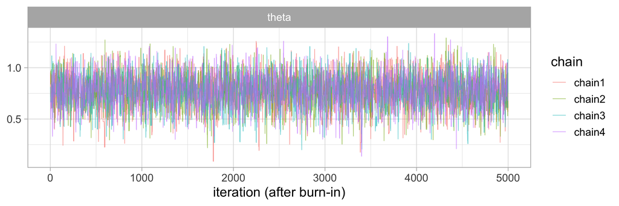

```r
trace_plot(pois_fit, "theta")
```

Good: all chains overlap and look like stationary noise (“hairy caterpillars”). Bad: trends, chains in different places, long flat stretches, occasional excursions.

### 6.3.2 $\widehat R$ (potential scale reduction factor)

$\widehat R$ compares the variation *between* chains with the variation *within* chains. If all chains sample the same distribution these agree and $\widehat R\approx1$. The modern, rank-normalised version (Vehtari et al., 2021, computed by the `posterior` package) also detects differences in the tails and in scale.

**Rule of thumb: $\widehat R<1.01$ for every parameter of interest.** (Older texts use 1.1; that threshold is too lax.) `coda::gelman.diag()` gives the original version.

### 6.3.3 Autocorrelation and effective sample size

MCMC draws are autocorrelated, so $S$ correlated draws carry less information than $S$ independent ones. The **effective sample size**

$$\text{ESS}=\frac{S}{1+2\sum_{t=1}^\infty\rho_t},$$

where $\rho_t$ is the lag-$t$ autocorrelation, is the number of independent draws with the same Monte Carlo precision. The MCSE of a posterior mean is $\text{sd}/\sqrt{\text{ESS}}$.

`posterior` reports two versions: **bulk-ESS** (reliability of means and medians) and **tail-ESS** (reliability of 2.5% and 97.5% quantiles, i.e. credible intervals). **Rule of thumb: both above 400** (100 per chain with 4 chains) before trusting summaries; more if you need precise tail probabilities.

```r
summarise_draws(as_draws(pois_fit), "mean", "sd", "rhat", "ess_bulk", "ess_tail", "mcse_mean")
```

```
# A tibble: 2 × 7
  variable  mean    sd  rhat ess_bulk ess_tail mcse_mean
  <chr>    <dbl> <dbl> <dbl>    <dbl>    <dbl>     <dbl>
1 lambda   2.20  0.351  1.00    4341.    4765.   0.00531
2 theta    0.777 0.160  1.00    4341.    4765.   0.00244
```

### 6.3.4 Burn-in, thinning, run length

- **Burn-in / warm-up**: discard the initial part of each chain (and the part during which samplers adapt their step sizes). Inspect trace plots from the very first iteration if in doubt; `NIMBLE`’s default of 0 burn-in is rarely appropriate.
- **Thinning** (keeping every $k$-th draw) *reduces* the information in the run. Use it only to save memory for very long runs of many parameters.
- **Run length**: increase `niter` until $\widehat R$ and ESS criteria are met. If this needs millions of iterations, fix the model or sampler instead (next section).

## 6.4 Case study: a sampler that mixes badly, and how to fix it

Simulated data for a linear regression with three covariates, one of which ($x_3$, a count with mean 20) is far from zero:

```r
set.seed(1309)
N <- 50
reg_df <- tibble(x1 = rexp(N, rate = 2),
                 x2 = rnorm(N, mean = -2, sd = 0.5),
                 x3 = rpois(N, lambda = 20)) |>
  mutate(y = 5 + x1 + 0.1 * x3 + rnorm(N, 0, 0.75))
```

$$Y_i=\beta_0+\beta_1x_{1i}+\beta_2x_{2i}+\beta_3x_{3i}+\varepsilon_i,\qquad\varepsilon_i\sim\mathcal N(0,\sigma^2).$$

```r
lm_code <- nimbleCode({
  for (i in 1:N) {
    y[i] ~ dnorm(mu[i], sd = sigma)
    mu[i] <- b0 + b1 * x1[i] + b2 * x2[i] + b3 * x3[i]
  }
  b0 ~ dnorm(0, sd = 10)
  b1 ~ dnorm(0, sd = 10)
  b2 ~ dnorm(0, sd = 10)
  b3 ~ dnorm(0, sd = 10)
  sigma ~ dexp(1)
})

lm_inits <- function() list(b0 = rnorm(1, 0, 3), b1 = rnorm(1), b2 = rnorm(1),
                            b3 = rnorm(1), sigma = runif(1, 0.5, 2))
```

```r
lm_fit_raw <- nimbleMCMC(
  code = lm_code, constants = list(N = N),
  data = list(y = reg_df$y, x1 = reg_df$x1, x2 = reg_df$x2, x3 = reg_df$x3),
  inits = lm_inits, monitors = c("b0", "b1", "b2", "b3", "sigma"),
  nchains = 4, niter = 3000, nburnin = 1000, setSeed = TRUE,
  progressBar = FALSE, samplesAsCodaMCMC = TRUE)
```

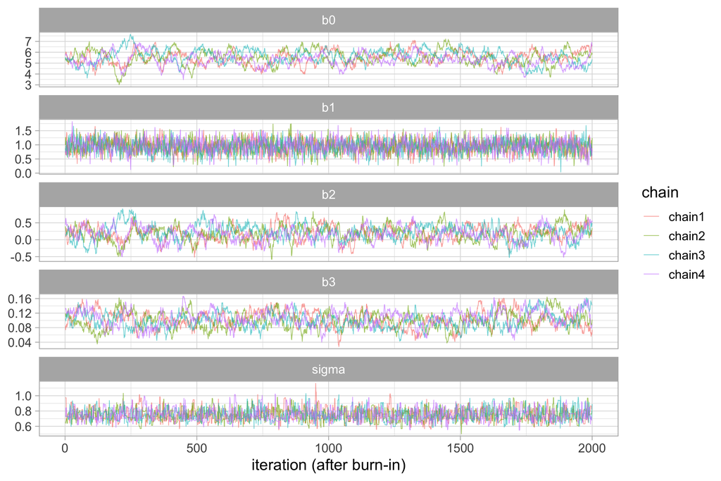

```r
trace_plot(lm_fit_raw)
```

```r
summarise_draws(as_draws(lm_fit_raw), "mean", "sd", "rhat", "ess_bulk", "ess_tail")
```

```
# A tibble: 5 × 6
  variable  mean     sd  rhat ess_bulk ess_tail
  <chr>    <dbl>  <dbl> <dbl>    <dbl>    <dbl>
1 b0       5.47  0.632   1.03     185.     415.
2 b1       0.950 0.226   1.00    1963.    3981.
3 b2       0.186 0.222   1.01     241.     410.
4 b3       0.102 0.0223  1.03     200.     459.
5 sigma    0.752 0.0791  1.00    1673.    1647.
```

The traces for $\beta_0$, $\beta_2$ and $\beta_3$ wander slowly and the ESS values are far below those of $\beta_1$ and $\sigma$. The reason is visible in a scatterplot of the draws:

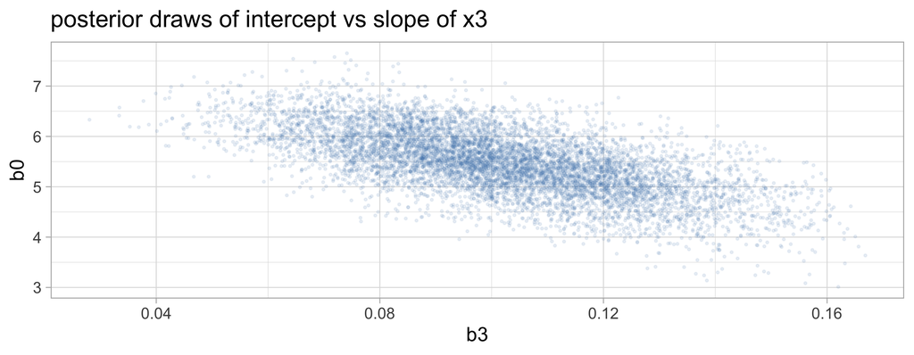

```r
as_tibble(as.matrix(lm_fit_raw)) |>
  ggplot(aes(b3, b0)) + geom_point(alpha = 0.1, size = 0.5, colour = "steelblue") +
  labs(title = "posterior draws of intercept vs slope of x3")
```

```r
round(cor(as.matrix(lm_fit_raw))[1:4, 1:4], 2)
```

```
      b0    b1    b2    b3
b0  1.00 -0.27  0.63 -0.65
b1 -0.27  1.00 -0.11  0.00
b2  0.63 -0.11  1.00  0.13
b3 -0.65  0.00  0.13  1.00
```

Because $x_2$ and $x_3$ are far from 0, the intercept (the expected outcome at $x_2=x_3=0$, far outside the data) is tightly linked to the slopes: whenever $\beta_3$ goes up, $\beta_0$ must go down to keep the fitted line through the data, and similarly for $\beta_2$. Jointly, the posterior of $(\beta_0,\beta_2,\beta_3)$ is a narrow ridge. `NIMBLE`’s default samplers here are exact conjugate Gibbs updates, but they update one coefficient at a time, holding the others fixed, and so can only take small steps along the ridge.

**Fix 1: centre the covariates.** With $x_j-\bar x_j$ the intercept becomes the expected outcome at average covariate values, and the correlation largely disappears. (Scaling covariates to unit SD also helps and makes priors easier to set.)

```r
reg_c <- reg_df |> mutate(across(c(x1, x2, x3), ~ .x - mean(.x)))

lm_fit_c <- nimbleMCMC(
  code = lm_code, constants = list(N = N),
  data = list(y = reg_c$y, x1 = reg_c$x1, x2 = reg_c$x2, x3 = reg_c$x3),
  inits = lm_inits, monitors = c("b0", "b1", "b2", "b3", "sigma"),
  nchains = 4, niter = 3000, nburnin = 1000, setSeed = TRUE,
  progressBar = FALSE, samplesAsCodaMCMC = TRUE)
```

```r
summarise_draws(as_draws(lm_fit_c), "mean", "sd", "rhat", "ess_bulk", "ess_tail")
```

```
# A tibble: 5 × 6
  variable  mean     sd  rhat ess_bulk ess_tail
  <chr>    <dbl>  <dbl> <dbl>    <dbl>    <dbl>
1 b0       7.76  0.109  1.00     7853.    7010.
2 b1       0.947 0.230  1.00     7836.    7586.
3 b2       0.206 0.238  1.00     7686.    7399.
4 b3       0.104 0.0236 1.000    7534.    7101.
5 sigma    0.753 0.0811 1.00     1471.    1805.
```

Same number of iterations, many times the effective sample size. The slopes are unchanged; only the meaning of the intercept changed (convert back if needed: $\beta_0^{\text{raw}}=\beta_0^{c}-\sum_j\beta_j\bar x_j$, computed draw by draw).

**Fix 2: change the sampler.** Keep the original parameterisation but update all four coefficients *jointly*, with a sampler that learns the correlation structure of the posterior. `NIMBLE`’s automated factor slice sampler (`AF_slice`) does this well:

```r
lm_model <- nimbleModel(lm_code, constants = list(N = N),
                        data = list(y = reg_df$y, x1 = reg_df$x1, x2 = reg_df$x2, x3 = reg_df$x3),
                        inits = lm_inits())
lm_conf <- configureMCMC(lm_model, monitors = c("b0", "b1", "b2", "b3", "sigma"))
lm_conf$removeSamplers(c("b0", "b1", "b2", "b3"))
lm_conf$addSampler(target = c("b0", "b1", "b2", "b3"), type = "AF_slice")

c_lm      <- compileNimble(lm_model)
c_lm_mcmc <- compileNimble(buildMCMC(lm_conf), project = lm_model)
lm_fit_block <- runMCMC(c_lm_mcmc, niter = 3000, nburnin = 1000, nchains = 4,
                        inits = lm_inits, setSeed = TRUE, progressBar = FALSE,
                        samplesAsCodaMCMC = TRUE)
```

```r
summarise_draws(as_draws(lm_fit_block), "mean", "sd", "rhat", "ess_bulk", "ess_tail")
```

```
# A tibble: 5 × 6
  variable  mean     sd  rhat ess_bulk ess_tail
  <chr>    <dbl>  <dbl> <dbl>    <dbl>    <dbl>
1 b0       5.46  0.676   1.00    8079.    5871.
2 b1       0.951 0.230   1.00    7137.    5685.
3 b2       0.208 0.237   1.00    8172.    6593.
4 b3       0.104 0.0233  1.00    7452.    6782.
5 sigma    0.755 0.0823  1.00    1548.    1821.
```

Same model, same number of iterations, and again an effective sample size close to the number of draws. Not every alternative sampler helps automatically: a random-walk block sampler (`RW_block`) is also available, but it needs a long adaptation phase before it becomes efficient, so its diagnostics must be checked just as carefully.

Finally, a sanity check: with vague priors and a simple model the posterior means should be close to the least-squares estimates.

```r
cbind(bayes_posterior_mean = colMeans(as.matrix(lm_fit_c))[c("b0", "b1", "b2", "b3")],
      least_squares        = coef(lm(y ~ x1 + x2 + x3, data = reg_c)))
```

```
   bayes_posterior_mean least_squares
b0            7.7574584     7.7573153
b1            0.9465793     0.9484755
b2            0.2063927     0.2087201
b3            0.1035333     0.1039762
```

## 6.5 What to do when diagnostics fail

In roughly this order:

1. **Look at trace and pair plots** to see *which* parameters mix badly and why (trends? correlations? stuck chains?).
2. **Check the model code and data** for errors (wrong parameterisation, precision instead of SD, data mis-coded). Many convergence problems are bugs.
3. **Reparameterise**: centre and scale covariates; use non-centred parameterisations for hierarchical models (Lecture 5); sample on unconstrained scales.
4. **Use more informative (weakly informative) priors** where parameters are poorly identified by the data.
5. **Change samplers**: block samplers for correlated parameters, slice samplers, HMC (`nimbleHMC` or `Stan`).
6. **Run longer.** This is the last resort, not the first.

**NotePractical 4**

Fit the Gamma-Poisson and non-conjugate Poisson models in `NIMBLE` and compare with exact / hand-coded results; full convergence assessment ($\widehat R$, bulk/tail ESS, MCSE, trace plots); diagnose and fix a poorly mixing regression (centring, block samplers); explore the effect of bad initial values and too-short burn-in.

# 7 Lecture 5: Bayesian regression, model checking and hierarchical models

## 7.1 A Bayesian workflow

Fitting a model is one step in an iterative process (Gelman et al., 2020):

1. **Formulate** a sampling model from subject-matter knowledge and the study design.
2. **Choose priors** and check them with **prior predictive simulation**.
3. **Fit** the model (MCMC) and **check the computation** ($\widehat R$, ESS, trace plots).
4. **Check the model** against the data: **posterior predictive checks**.
5. **Compare / expand** models where checks reveal problems; compare by **predictive performance** (LOO, WAIC).
6. **Summarise and report** posterior quantities that answer the scientific question, with sensitivity analyses.

This lecture goes through the loop with three examples typical of biostatistics.

## 7.2 Logistic regression

**Example (simulated).** In a household survey, 300 children aged 6 months to 5 years were tested for anaemia. We want the association with bed-net use, adjusted for age.

```r
set.seed(2025)
N_c <- 300
anaemia_df <- tibble(age = runif(N_c, 0.5, 5),
                     net = rbinom(N_c, 1, 0.6)) |>
  mutate(anaemia = rbinom(N_c, 1, plogis(-0.5 - 0.4 * (age - 2.75) - 0.8 * net)),
         age_c   = age - mean(age))

anaemia_df |> group_by(net) |> summarise(n = n(), prevalence = mean(anaemia))
```

```
# A tibble: 2 × 3
    net     n prevalence
  <int> <int>      <dbl>
1     0   125      0.408
2     1   175      0.274
```

Model:

$$Y_i\sim\text{Bernoulli}(p_i),\qquad \text{logit}(p_i)=\beta_0+\beta_{\text{age}}\,(\text{age}_i-\overline{\text{age}})+\beta_{\text{net}}\,\text{net}_i.$$

### 7.2.1 Priors, checked on interpretable scales

The model has two kinds of coefficient, on different scales, so they get different priors and different checks.

**The intercept.** $\beta_0$ is the log-odds of anaemia for a child of average age without a net. We know anaemia is common but not universal in this population, and we want a prior that allows any plausible prevalence. The quantity to check is therefore the implied **prevalence**, $\text{logit}^{-1}(\beta_0)$. We compare $\beta_0\sim\mathcal N(0,1.5^2)$ with the “vague” $\mathcal N(0,100^2)$ often seen in older code:

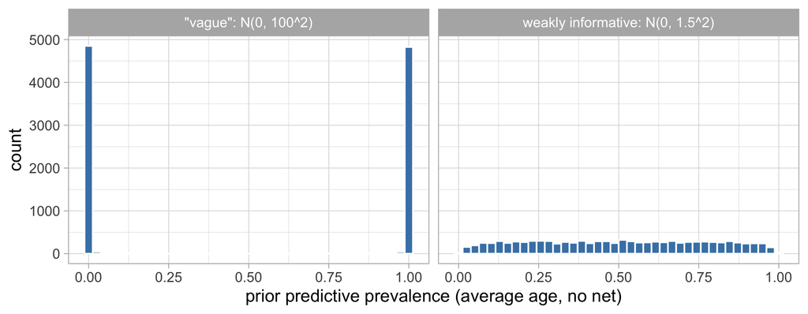

```r
S <- 1e4
tibble(`weakly informative: N(0, 1.5^2)` = plogis(rnorm(S, 0, 1.5)),
       `"vague": N(0, 100^2)`           = plogis(rnorm(S, 0, 100))) |>
  pivot_longer(everything()) |>
  ggplot(aes(value)) + geom_histogram(bins = 40, fill = "steelblue", colour = "white") +
  facet_wrap(~name) +
  labs(x = "prior predictive prevalence (average age, no net)", y = "count")
```

$\mathcal N(0,1.5^2)$ spreads prevalence across the whole range without piling up at the extremes. The “vague” prior claims that prevalence is almost certainly either close to 0% or close to 100%: it is anything but uninformative.

**The slopes.** $\beta_{\text{net}}$ and $\beta_{\text{age}}$ are log odds ratios: *differences* in log-odds. Here the question is how large an effect is plausible, so the quantity to check is the implied **odds ratio** $e^{\beta}$. We use $\mathcal N(0,1)$:

```r
quantile(exp(rnorm(S, 0, 1)), c(0.025, 0.5, 0.975))   # implied prior for an odds ratio
```

```
     2.5%       50%     97.5%
0.1348073 0.9904853 7.1473704
```

This gives odds ratios between about 0.14 and 7 with 95% prior probability, which comfortably covers realistic effects of an exposure such as bed-net use while ruling out absurd ones (an odds ratio of 1000). The slopes get a smaller SD than the intercept because effects are usually more constrained than baselines: prevalence could plausibly be anywhere from 5% to 90%, but an exposure that multiplies the odds by 20 is rare. $\mathcal N(0,1.5^2)$ for the slopes would be equally defensible. With 300 children the choice hardly matters: the standard error of $\beta_{\text{net}}$ is about 0.25, so its posterior mean is shrunk towards 0 by roughly 6% under $\mathcal N(0,1)$ and 3% under $\mathcal N(0,1.5^2)$. What matters is avoiding $\mathcal N(0,100^2)$, which puts most of its mass on odds ratios above $10^{20}$ or below $10^{-20}$.

**Note**

$\beta_{\text{age}}$ is per year of age, so across the 4.5-year age range the $\mathcal N(0,1)$ prior still allows a very large cumulative age effect. If covariates are on very different scales, standardise them first so that one prior SD makes sense for all slopes.

### 7.2.2 Fitting the model

```r
logit_code <- nimbleCode({
  for (i in 1:N) {
    anaemia[i] ~ dbern(p[i])
    logit(p[i]) <- b0 + b_age * age_c[i] + b_net * net[i]
  }
  b0    ~ dnorm(0, sd = 1.5)
  b_age ~ dnorm(0, sd = 1)
  b_net ~ dnorm(0, sd = 1)
})
```

```r
logit_fit <- nimbleMCMC(
  code = logit_code,
  constants = list(N = N_c, age_c = anaemia_df$age_c, net = anaemia_df$net),
  data = list(anaemia = anaemia_df$anaemia),
  inits = function() list(b0 = rnorm(1), b_age = rnorm(1, 0, 0.5), b_net = rnorm(1, 0, 0.5)),
  monitors = c("b0", "b_age", "b_net"),
  nchains = 4, niter = 6000, nburnin = 1000, setSeed = TRUE,
  progressBar = FALSE, samplesAsCodaMCMC = TRUE)
```

```r
summarise_draws(as_draws(logit_fit), "mean", "sd", ~quantile(.x, c(0.025, 0.975)), "rhat", "ess_bulk", "ess_tail")
```

```
# A tibble: 3 × 8
  variable   mean     sd `2.5%` `97.5%`  rhat ess_bulk ess_tail
  <chr>     <dbl>  <dbl>  <dbl>   <dbl> <dbl>    <dbl>    <dbl>
1 b0       -0.370 0.181  -0.729 -0.0212  1.00    1517.    2864.
2 b_age    -0.319 0.0958 -0.507 -0.133   1.00    4682.    4410.
3 b_net    -0.659 0.245  -1.13  -0.160   1.00    1537.    2763.
```

### 7.2.3 Answering questions on interpretable scales

From the draws, any quantity is one line away: the odds ratio for bed nets, the probability that nets are protective, and the risk difference at a given age.

```r
dr <- as.matrix(logit_fit)
or_net <- exp(dr[, "b_net"])

age_ref <- 2 - mean(anaemia_df$age)                        # a 2-year-old
p_no_net <- plogis(dr[, "b0"] + dr[, "b_age"] * age_ref)
p_net    <- plogis(dr[, "b0"] + dr[, "b_age"] * age_ref + dr[, "b_net"])

rbind(`odds ratio (net)`             = quantile(or_net, c(0.5, 0.025, 0.975)),
      `risk difference, age 2 (pp)`  = 100 * quantile(p_no_net - p_net, c(0.5, 0.025, 0.975)))
```

```
                                   50%      2.5%      97.5%
odds ratio (net)             0.5164705 0.3224355  0.8525431
risk difference, age 2 (pp) 15.5575111 3.7939897 26.3455871
```

```r
c(`P(OR < 1 | data)` = mean(or_net < 1),
  `P(risk difference > 10 pp | data)` = mean(p_no_net - p_net > 0.10))
```

```
                 P(OR < 1 | data) P(risk difference > 10 pp | data)
                          0.99625                           0.83510
```

Predicted prevalence by age, with 95% credible bands:

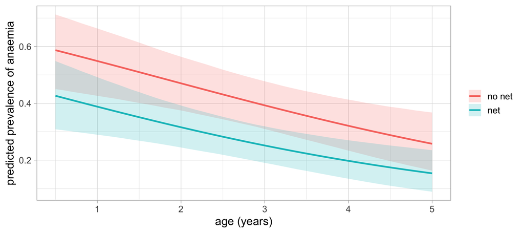

```r
pred <- expand_grid(age = seq(0.5, 5, by = 0.1), net = 0:1) |>
  mutate(draws = map2(age, net, ~ plogis(dr[, "b0"] + dr[, "b_age"] * (.x - mean(anaemia_df$age)) +
                                           dr[, "b_net"] * .y)),
         mean = map_dbl(draws, mean),
         lo   = map_dbl(draws, ~ quantile(.x, 0.025)),
         hi   = map_dbl(draws, ~ quantile(.x, 0.975)),
         net  = factor(net, labels = c("no net", "net")))

ggplot(pred, aes(age, mean, colour = net, fill = net)) +
  geom_ribbon(aes(ymin = lo, ymax = hi), alpha = 0.2, colour = NA) +
  geom_line(linewidth = 1) +
  labs(x = "age (years)", y = "predicted prevalence of anaemia", colour = NULL, fill = NULL)
```

## 7.3 Posterior predictive checks

A model can fit perfectly in the MCMC sense (great $\widehat R$, great ESS) and still be a poor description of the data. **Posterior predictive checks** compare the observed data with data *replicated* from the fitted model:

1. For $s=1,\ldots,S$: take a posterior draw $\theta^{(s)}$ and simulate a full replicated dataset $\mathbf y^{\text{rep}(s)}\sim p(\mathbf y\mid\theta^{(s)})$ of the same size and covariates as the observed data.
2. Choose test statistics $T(\mathbf y)$ that capture features the model *should* reproduce and that matter for the question (proportion of zeros, variance, maximum, number of runs, group differences…).
3. Compare $T(\mathbf y)$ with the distribution of $T(\mathbf y^{\text{rep}(s)})$. The **posterior predictive p-value** $P\left(T(\mathbf y^{\text{rep}})\geq T(\mathbf y)\mid\mathbf y\right)$ close to 0 or 1 flags a misfit.

**Important**

Step 1 must use a **different parameter draw for each replicated dataset**. Simulating all replicates from a single point estimate (e.g. the posterior mean) ignores parameter uncertainty and makes the check too severe.

### 7.3.1 Example: over-dispersed counts

Malaria episodes per child in one year, for 200 children, by whether their household has an insecticide-treated net (ITN) (simulated data):

```r
set.seed(7)
N_k <- 200
malaria_df <- tibble(itn = rbinom(N_k, 1, 0.5)) |>
  mutate(episodes = rnbinom(N_k, size = 1.2, mu = exp(0.6 - 0.5 * itn)))

malaria_df |> group_by(itn) |>
  summarise(n = n(), mean = mean(episodes), variance = var(episodes), zeros = mean(episodes == 0))
```

```
# A tibble: 2 × 5
    itn     n  mean variance zeros
  <int> <int> <dbl>    <dbl> <dbl>
1     0    95  1.8      6.84 0.4
2     1   105  1.12     2.11 0.457
```

We fit a Poisson regression and a negative binomial regression. The negative binomial has an extra dispersion parameter $\phi$ with $\text{Var}(Y)=\mu+\phi\mu^2$; $\phi\to0$ recovers the Poisson.

```r
pois_reg_code <- nimbleCode({
  for (i in 1:N) {
    y[i] ~ dpois(mu[i])
    log(mu[i]) <- a0 + a1 * itn[i]
  }
  a0 ~ dnorm(0, sd = 1.5)
  a1 ~ dnorm(0, sd = 1)
})

nb_reg_code <- nimbleCode({
  for (i in 1:N) {
    y[i] ~ dnegbin(prob[i], r)        # NIMBLE/BUGS order: probability first, then size
    prob[i] <- r / (r + mu[i])
    log(mu[i]) <- a0 + a1 * itn[i]
  }
  a0  ~ dnorm(0, sd = 1.5)
  a1  ~ dnorm(0, sd = 1)
  phi ~ dexp(1)                        # over-dispersion; phi -> 0 is the Poisson model
  r  <- 1 / phi
})
```

```r
count_consts <- list(N = N_k, itn = malaria_df$itn)
count_data   <- list(y = malaria_df$episodes)

pois_reg_fit <- nimbleMCMC(pois_reg_code, constants = count_consts, data = count_data,
  inits = function() list(a0 = rnorm(1, 0, 0.5), a1 = rnorm(1, 0, 0.5)),
  monitors = c("a0", "a1"), nchains = 4, niter = 6000, nburnin = 1000,
  setSeed = TRUE, progressBar = FALSE, samplesAsCodaMCMC = TRUE)

nb_reg_fit <- nimbleMCMC(nb_reg_code, constants = count_consts, data = count_data,
  inits = function() list(a0 = rnorm(1, 0, 0.5), a1 = rnorm(1, 0, 0.5), phi = runif(1, 0.2, 2)),
  monitors = c("a0", "a1", "phi"), nchains = 4, niter = 6000, nburnin = 1000,
  setSeed = TRUE, progressBar = FALSE, samplesAsCodaMCMC = TRUE)
```

```r
summarise_draws(as_draws(pois_reg_fit), "mean", "sd", ~quantile(.x, c(0.025, 0.975)), "rhat", "ess_bulk")
```

```
# A tibble: 2 × 7
  variable   mean     sd `2.5%` `97.5%`  rhat ess_bulk
  <chr>     <dbl>  <dbl>  <dbl>   <dbl> <dbl>    <dbl>
1 a0        0.580 0.0761  0.426   0.725  1.00    1950.
2 a1       -0.465 0.117  -0.699  -0.236  1.00    1952.
```

```r
summarise_draws(as_draws(nb_reg_fit),   "mean", "sd", ~quantile(.x, c(0.025, 0.975)), "rhat", "ess_bulk")
```

```
# A tibble: 3 × 7
  variable   mean    sd `2.5%` `97.5%`  rhat ess_bulk
  <chr>     <dbl> <dbl>  <dbl>   <dbl> <dbl>    <dbl>
1 a0        0.575 0.133  0.315  0.835   1.00    1676.
2 a1       -0.447 0.190 -0.817 -0.0750  1.00    1726.
3 phi       1.15  0.217  0.767  1.61    1.00    4677.
```

Both models give similar point estimates of the ITN rate ratio $e^{a_1}$, but the Poisson model’s credible interval is narrower. Is that extra certainty justified? Posterior predictive check:

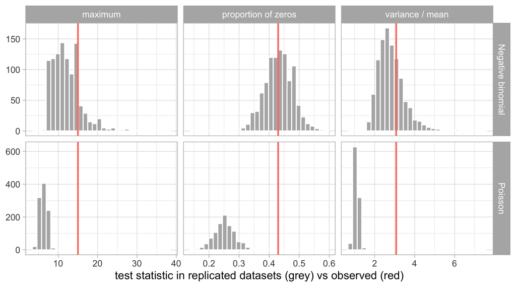

```r
ppc_counts <- function(fit, model, n_rep = 1000) {
  dr <- as.matrix(fit)
  idx <- sample(nrow(dr), n_rep)
  map_dfr(idx, function(s) {                         # one posterior draw per replicate
    mu <- exp(dr[s, "a0"] + dr[s, "a1"] * malaria_df$itn)
    y_rep <- if (model == "Poisson") rpois(N_k, mu) else rnbinom(N_k, size = 1 / dr[s, "phi"], mu = mu)
    tibble(`proportion of zeros` = mean(y_rep == 0),
           `variance / mean`     = var(y_rep) / mean(y_rep),
           `maximum`             = max(y_rep))
  }) |> mutate(model = model)
}

set.seed(11)
ppc <- bind_rows(ppc_counts(pois_reg_fit, "Poisson"), ppc_counts(nb_reg_fit, "Negative binomial")) |>
  pivot_longer(-model, names_to = "statistic")

observed <- tibble(`proportion of zeros` = mean(malaria_df$episodes == 0),
                   `variance / mean`     = var(malaria_df$episodes) / mean(malaria_df$episodes),
                   `maximum`             = max(malaria_df$episodes)) |>
  pivot_longer(everything(), names_to = "statistic", values_to = "observed")

ggplot(ppc, aes(value)) +
  geom_histogram(bins = 30, fill = "grey70", colour = "white") +
  geom_vline(data = observed, aes(xintercept = observed), colour = "salmon", linewidth = 1) +
  facet_grid(model ~ statistic, scales = "free") +
  labs(x = "test statistic in replicated datasets (grey) vs observed (red)", y = NULL)
```

```r
ppc |> left_join(observed, by = "statistic") |>
  group_by(model, statistic) |>
  summarise(`posterior predictive p-value` = mean(value >= observed), .groups = "drop")
```

```
# A tibble: 6 × 3
  model             statistic           `posterior predictive p-value`
  <chr>             <chr>                                        <dbl>
1 Negative binomial maximum                                      0.211
2 Negative binomial proportion of zeros                          0.538
3 Negative binomial variance / mean                              0.29
4 Poisson           maximum                                      0
5 Poisson           proportion of zeros                          0
6 Poisson           variance / mean                              0
```

The Poisson model cannot reproduce the number of children with no episodes, nor the spread of the data: its posterior predictive p-values are essentially 0. The negative binomial reproduces all three features. Conclusion: the Poisson model is over-confident about the ITN effect, and the negative binomial model should be used.

## 7.4 Comparing models by predictive accuracy

Posterior predictive checks tell us *whether* a model is inadequate and *how*. To choose between adequate models we ask which predicts **new** data best. The expected log predictive density for a new observation can be estimated by **leave-one-out cross-validation (LOO)**, without refitting the model $n$ times, using Pareto-smoothed importance sampling (Vehtari et al., 2017). **WAIC** is an asymptotically equivalent, slightly less robust alternative (`NIMBLE` can compute it with `WAIC = TRUE`).

Both need the **pointwise log-likelihood** $\log p(y_i\mid\theta^{(s)})$ for every draw $s$ and observation $i$, which is easy to compute from the draws:

```r
loglik_counts <- function(fit, model) {
  dr <- as.matrix(fit)
  mu <- exp(dr[, "a0"] + outer(dr[, "a1"], malaria_df$itn))       # S x N matrix
  Y  <- matrix(malaria_df$episodes, nrow = nrow(dr), ncol = N_k, byrow = TRUE)
  ll <- if (model == "Poisson") dpois(Y, mu, log = TRUE) else
          dnbinom(Y, size = 1 / dr[, "phi"], mu = mu, log = TRUE)
  matrix(ll, nrow = nrow(dr))
}

loo_from_ll <- function(ll, nchains = 4) {
  chain_id <- rep(seq_len(nchains), each = nrow(ll) / nchains)
  loo(ll, r_eff = relative_eff(exp(ll), chain_id = chain_id))
}

loo_pois <- loo_from_ll(loglik_counts(pois_reg_fit, "Poisson"))
loo_nb   <- loo_from_ll(loglik_counts(nb_reg_fit,  "Negative binomial"))
lc <- loo_compare(list(Poisson = loo_pois, `Negative binomial` = loo_nb))
lc
```

```
                  elpd_diff se_diff
Negative binomial   0.0       0.0
Poisson           -57.0      19.9
```

`elpd_diff` is the difference in expected log predictive density relative to the best model, with its standard error. Here the Poisson model is about 57 units of elpd worse, 2.9 standard errors: clear evidence in favour of the negative binomial model. Also look at the Pareto $k$ diagnostics printed by `loo()`; values above 0.7 flag observations for which the LOO estimate is unreliable (often influential outliers).

**Tip**

Model comparison is not a substitute for thinking. Prefer the model that is scientifically justified and passes predictive checks; use LOO to arbitrate between such models or to decide whether added complexity pays for itself.

## 7.5 Hierarchical models: the natural home of Bayesian methods

**Example (illustrative data).** In-hospital mortality among children admitted with severe malaria at eight district hospitals:

```r
hosp <- tibble(hospital = LETTERS[1:8],
               n        = c(45, 120, 32, 210, 18, 76, 150, 9),
               deaths   = c( 6,  11,  5,  17,  4,  7,  12, 3))
hosp |> mutate(raw_rate = deaths / n)
```

```
# A tibble: 8 × 4
  hospital     n deaths raw_rate
  <chr>    <dbl>  <dbl>    <dbl>
1 A           45      6   0.133
2 B          120     11   0.0917
3 C           32      5   0.156
4 D          210     17   0.0810
5 E           18      4   0.222
6 F           76      7   0.0921
7 G          150     12   0.08
8 H            9      3   0.333
```

Hospital H has 3 deaths in 9 admissions (33%). Is it really the worst hospital, or just the smallest? Three modelling options:

- **Complete pooling**: one common mortality for all hospitals. Ignores genuine differences.
- **No pooling**: a separate, unrelated estimate for each hospital. Small hospitals get extreme, very uncertain estimates.
- **Partial pooling (hierarchical model)**: hospital-specific mortalities that are *related*, drawn from a common population distribution whose spread is estimated from the data.

Concretely, the partial-pooling model we will fit is

$$\begin{aligned}
\text{deaths}_j\mid p_j&\sim\text{Bin}(n_j,p_j), & \eta_j&=\text{logit}(p_j),\\
\eta_j\mid\mu,\sigma&\sim\mathcal N(\mu,\sigma^2), & \mu&\sim\mathcal N(-2,1^2),\quad\sigma\sim\text{Exp}(1),
\end{aligned}$$

for hospitals $j=1,\ldots,8$. Here $\eta_j$ is hospital $j$’s true log-odds of death; $\mu$ is the typical log-odds across district hospitals (the prior is centred on $\text{logit}^{-1}(-2)\approx12\%$); and $\sigma$ is the between-hospital SD on the log-odds scale. The other two options are limiting cases: complete pooling is $\sigma=0$, and no pooling corresponds roughly to $\sigma\to\infty$. The rest of this section explains why this structure is justified, and then fits it.

Complete pooling is clearly too strong: the hospitals differ in staffing, case mix and access. But why should partial pooling be legitimate? Why should data from hospital A change our estimate for hospital H? The answer is exchangeability.

### 7.5.1 Exchangeability

A set of unknown quantities $\eta_1,\ldots,\eta_J$ is **exchangeable** if their joint distribution does not change when the labels are permuted:

$$p(\eta_1,\ldots,\eta_J)=p(\eta_{\rho(1)},\ldots,\eta_{\rho(J)})\qquad\text{for every permutation }\rho\text{ of }1,\ldots,J.$$

In words: *before seeing the data*, we have no information that distinguishes one from another. If someone secretly swapped the hospital names, our beliefs would be the same. Here the exchangeable quantities are the hospitals’ true log-odds of death, $\eta_j=\text{logit}(p_j)$.

Exchangeable does **not** mean independent. If we learned that hospital A has 20% mortality, that would reasonably change what we expect for hospital H: it tells us something about the level of mortality in district hospitals generally. That is exactly the kind of dependence partial pooling uses.

### 7.5.2 De Finetti’s theorem

Informally, de Finetti’s theorem says that if a sequence $\eta_1,\eta_2,\ldots$ is exchangeable (and could in principle be extended indefinitely, e.g. to hospitals we have not sampled), then its joint distribution can always be written as

$$p(\eta_1,\ldots,\eta_J)=\int\prod_{j=1}^J p(\eta_j\mid\phi)\;p(\phi)\,d\phi.$$

That is: the $\eta_j$ are **independent and identically distributed given some parameter $\phi$**, and $\phi$ itself is unknown and has a distribution. Exchangeability, a simple symmetry judgement, forces this structure.

We have used this twice in the course:

| Level | Exchangeable quantities | What de Finetti gives | Model |
| --- | --- | --- | --- |
| Data (Lecture 1) | Test results of the 30 children | i.i.d. given prevalence $\pi$, plus a prior on $\pi$ | $Y_i\mid\pi\sim\text{Bernoulli}(\pi)$, $\pi\sim\text{Beta}(a,b)$ |
| Parameters (here) | Log-odds of death at the 8 hospitals | i.i.d. given $\phi=(\mu,\sigma)$, plus a prior on $(\mu,\sigma)$ | $\eta_j\mid\mu,\sigma\sim\mathcal N(\mu,\sigma^2)$, priors on $\mu,\sigma$ |

So the hierarchical model is not an ad hoc device: it is what exchangeability of the hospitals implies. Two caveats: the theorem guarantees the *structure* (i.i.d. given $\phi$, plus a prior on $\phi$), not the *shape*; choosing a normal distribution for $\eta_j\mid\mu,\sigma$ is our modelling decision, and can be checked like any other. And for a finite set of hospitals that could not be extended the representation holds only approximately, which in practice is rarely a concern.

### 7.5.3 Exchangeable but dependent: where the pooling comes from

We can see the dependence directly by simulating from the prior of the model above: draw $\mu\sim\mathcal N(-2,1^2)$ and $\sigma\sim\text{Exp}(1)$, then two hospitals’ log-odds independently from $\mathcal N(\mu,\sigma^2)$.

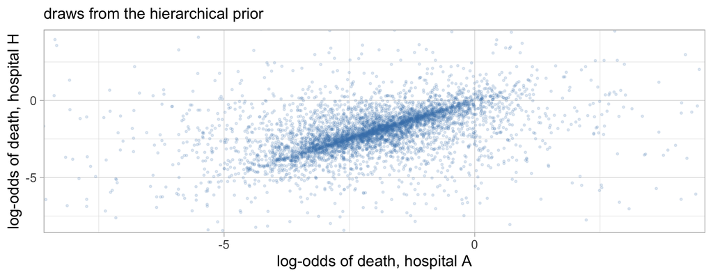

```r
S <- 5000
mu_s    <- rnorm(S, -2, 1)
sigma_s <- rexp(S, 1)
eta_A   <- rnorm(S, mu_s, sigma_s)
eta_H   <- rnorm(S, mu_s, sigma_s)

ggplot(tibble(eta_A, eta_H), aes(eta_A, eta_H)) +
  geom_point(alpha = 0.15, size = 0.6, colour = "steelblue") +
  coord_cartesian(xlim = c(-8, 4), ylim = c(-8, 4)) +
  labs(x = "log-odds of death, hospital A", y = "log-odds of death, hospital H",
       subtitle = "draws from the hierarchical prior")
```

```r
cor(eta_A, eta_H)
```

```
[1] 0.3330657
```

The two hospitals are exchangeable (the plot is symmetric about the diagonal) but positively correlated a priori, because they share the unknown $\mu$. This correlation is what makes data from hospital A informative about hospital H.

The correlation can be derived exactly by conditioning on $(\mu,\sigma)$ and using the laws of total variance and total covariance (Appendix A). Given $(\mu,\sigma)$, $\eta_A$ and $\eta_H$ are independent, each with mean $\mu$ and variance $\sigma^2$, so

$$\begin{aligned}
\text{Var}(\eta_j)&=E\big[\text{Var}(\eta_j\mid\mu,\sigma)\big]+\text{Var}\big(E[\eta_j\mid\mu,\sigma]\big)=E[\sigma^2]+\text{Var}(\mu),\\
\text{Cov}(\eta_A,\eta_H)&=E\big[\text{Cov}(\eta_A,\eta_H\mid\mu,\sigma)\big]+\text{Cov}\big(E[\eta_A\mid\mu,\sigma],E[\eta_H\mid\mu,\sigma]\big)=0+\text{Cov}(\mu,\mu)=\text{Var}(\mu).
\end{aligned}$$

With $\mu\sim\mathcal N(-2,1^2)$, $\text{Var}(\mu)=1$. With $\sigma\sim\text{Exp}(1)$, $E[\sigma]=1$ and $\text{Var}(\sigma)=1$, so $E[\sigma^2]=\text{Var}(\sigma)+E[\sigma]^2=2$. Hence $\text{Var}(\eta_j)=1+2=3$, $\text{Cov}(\eta_A,\eta_H)=1$, and the prior correlation is $1/3$. (The simulated value differs slightly from $1/3$: with 5,000 draws its Monte Carlo SD is about 0.02.)

The formula also shows what drives the pooling: the more uncertain the shared level $\mu$ is, relative to the spread $\sigma$ between hospitals, the more strongly the hospitals are linked.

The three modelling options are then three beliefs about the hospitals:

- **Complete pooling** ($\sigma=0$): the hospitals are identical. Stronger than exchangeability, and implausible.
- **No pooling** (independent, vague priors on each $\eta_j$, roughly $\sigma\to\infty$): data from seven hospitals tell us *nothing* about the eighth. Also implausible.
- **Partial pooling**: the hospitals are exchangeable, and the data decide through $\sigma$ how similar they are.

### 7.5.4 When exchangeability fails

Exchangeability is a judgement made before seeing the data, and it can be wrong. Suppose hospital H is a referral centre that receives the sickest children, or two of the hospitals have paediatric high-dependency units. Then we *can* tell the hospitals apart in a way that matters for mortality, and pooling H’s estimate towards the district average would be a mistake.

The remedy is **conditional exchangeability**: the hospitals are exchangeable *given* the relevant covariates. Put the information in the model,

$$\eta_j\mid\mu,\beta,\sigma\sim\mathcal N(\mu+\beta\,x_j,\ \sigma^2),$$

for example with $x_j=1$ for referral centres. Each hospital’s estimate is then pooled towards the value predicted for hospitals like it, not towards the overall mean. The same logic applies at the data level: patients admitted before and after a power cut, or children from different villages, are not exchangeable, and the model must say so (for example with a covariate or a village-level random effect).

A useful question to ask before fitting any hierarchical model: *before seeing the outcome data, is there anything I know that distinguishes these groups and plausibly affects the outcome?* If yes, it belongs in the model.

### 7.5.5 Fitting the model

For fitting, we write the same model in an equivalent form, with $\eta_j=\mu+\sigma z_j$:

$$\begin{aligned}
\text{deaths}_j\mid p_j&\sim\text{Bin}(n_j,p_j), & \text{logit}(p_j)&=\mu+\sigma z_j,\\
z_j&\sim\mathcal N(0,1), & \mu&\sim\mathcal N(-2,1^2),\quad\sigma\sim\text{Exp}(1).
\end{aligned}$$

If $z_j\sim\mathcal N(0,1)$, then $\mu+\sigma z_j\sim\mathcal N(\mu,\sigma^2)$, so this is the same model as before. It is exactly a logistic regression with a random intercept for hospital (a GLMM), estimated by MCMC. Writing $\text{logit}(p_j)=\mu+\sigma z_j$ with standard normal $z_j$ (rather than $\text{logit}(p_j)\sim\mathcal N(\mu,\sigma^2)$) is the **non-centred parameterisation**. It is mathematically equivalent but avoids the “funnel” geometry that makes samplers struggle when groups are small and $\sigma$ is poorly determined.

```r
hier_code <- nimbleCode({
  for (j in 1:J) {
    deaths[j] ~ dbin(p[j], n[j])
    logit(p[j]) <- mu + sigma * z[j]
    z[j] ~ dnorm(0, sd = 1)
  }
  mu    ~ dnorm(-2, sd = 1)
  sigma ~ dexp(1)
})
```

```r
hier_fit <- nimbleMCMC(hier_code,
  constants = list(J = nrow(hosp), n = hosp$n),
  data = list(deaths = hosp$deaths),
  inits = function() list(mu = rnorm(1, -2, 0.5), sigma = runif(1, 0.1, 1), z = rnorm(nrow(hosp))),
  monitors = c("mu", "sigma", "p", "z"), nchains = 4, niter = 11000, nburnin = 1000,
  setSeed = TRUE, progressBar = FALSE, samplesAsCodaMCMC = TRUE)
```

```r
hier_fit |> as_draws() |> subset_draws(variable = c("mu", "sigma", "p")) |>
  summarise_draws("median", ~quantile(.x, c(0.025, 0.975)), "rhat", "ess_bulk", "ess_tail")
```

```
# A tibble: 10 × 7
   variable  median   `2.5%` `97.5%`  rhat ess_bulk ess_tail
   <chr>      <dbl>    <dbl>   <dbl> <dbl>    <dbl>    <dbl>
 1 mu       -2.16   -2.50     -1.70   1.00    2283.    2491.
 2 sigma     0.208   0.00931   0.828  1.00    1941.    2592.
 3 p[1]      0.106   0.0701    0.185  1.00    5745.    9166.
 4 p[2]      0.0980  0.0639    0.138  1.00    9543.   10918.
 5 p[3]      0.108   0.0710    0.204  1.00    4693.    7839.
 6 p[4]      0.0930  0.0618    0.125  1.00    8730.   14240.
 7 p[5]      0.110   0.0726    0.245  1.00    3784.    5450.
 8 p[6]      0.0992  0.0619    0.148  1.00    8247.   10966.
 9 p[7]      0.0942  0.0601    0.129  1.00    8496.   11224.
10 p[8]      0.111   0.0720    0.286  1.00    3570.    4729.
```

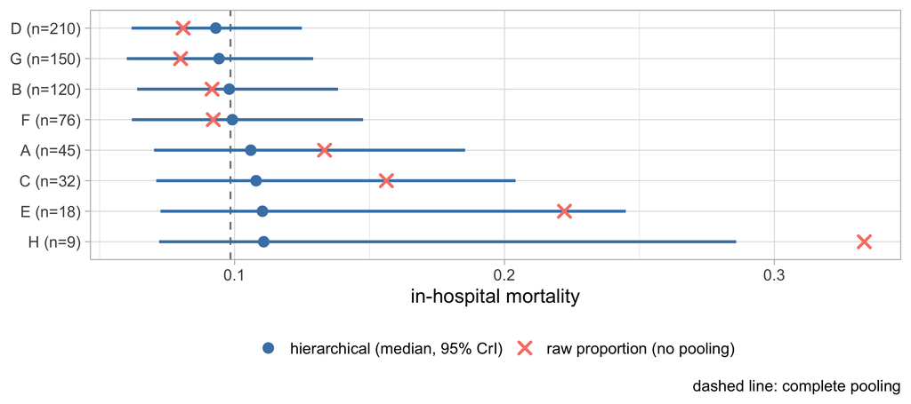

```r
dr_h <- as.matrix(hier_fit)
p_draws <- dr_h[, paste0("p[", 1:nrow(hosp), "]")]

hosp_summ <- hosp |>
  mutate(raw     = deaths / n,
         partial = apply(p_draws, 2, median),
         lo      = apply(p_draws, 2, quantile, 0.025),
         hi      = apply(p_draws, 2, quantile, 0.975),
         `P(mortality > 15%)` = colMeans(p_draws > 0.15),
         label   = paste0(hospital, " (n=", n, ")"),
         label   = fct_reorder(label, n))

ggplot(hosp_summ, aes(y = label)) +
  geom_vline(xintercept = sum(hosp$deaths) / sum(hosp$n), linetype = 2, colour = "grey50") +
  geom_linerange(aes(xmin = lo, xmax = hi), colour = "steelblue", linewidth = 1) +
  geom_point(aes(x = partial, colour = "hierarchical (median, 95% CrI)"), size = 3) +
  geom_point(aes(x = raw, colour = "raw proportion (no pooling)"), size = 3, shape = 4, stroke = 1.5) +
  scale_colour_manual(values = c("steelblue", "salmon")) +
  labs(x = "in-hospital mortality", y = NULL, colour = NULL,
       caption = "dashed line: complete pooling") +
  theme(legend.position = "bottom")
```

```r
hosp_summ |> select(hospital, n, raw, partial, `P(mortality > 15%)`) |> kable(digits = 3)
```

| hospital | n | raw | partial | P(mortality > 15%) |
| --- | --- | --- | --- | --- |
| A | 45 | 0.133 | 0.106 | 0.095 |
| B | 120 | 0.092 | 0.098 | 0.009 |
| C | 32 | 0.156 | 0.108 | 0.129 |
| D | 210 | 0.081 | 0.093 | 0.001 |
| E | 18 | 0.222 | 0.110 | 0.181 |
| F | 76 | 0.092 | 0.099 | 0.021 |
| G | 150 | 0.080 | 0.094 | 0.002 |
| H | 9 | 0.333 | 0.111 | 0.206 |

Estimates are **shrunk** towards the overall mean, and small hospitals are shrunk the most, because their own data carry the least information. Hospital H’s estimate moves a long way towards the average and its interval stays wide: the data do not support singling it out. Large hospitals barely move. The amount of shrinkage is not chosen by the analyst; it is learned from the data through $\sigma$.

### 7.5.6 Why the non-centred parameterisation? A pair plot

The same model can be written in the **centred** parameterisation, with the hospital log-odds $\theta_j$ as parameters:

$$\text{logit}(p_j)=\theta_j,\qquad\theta_j\sim\mathcal N(\mu,\sigma^2).$$

```r
hier_code_c <- nimbleCode({
  for (j in 1:J) {
    deaths[j] ~ dbin(p[j], n[j])
    logit(p[j]) <- theta[j]
    theta[j] ~ dnorm(mu, sd = sigma)
  }
  mu    ~ dnorm(-2, sd = 1)
  sigma ~ dexp(1)
})

hier_fit_c <- nimbleMCMC(hier_code_c,
  constants = list(J = nrow(hosp), n = hosp$n),
  data = list(deaths = hosp$deaths),
  inits = function() list(mu = rnorm(1, -2, 0.5), sigma = runif(1, 0.1, 1), theta = rnorm(nrow(hosp), -2, 0.3)),
  monitors = c("mu", "sigma", "theta"), nchains = 4, niter = 11000, nburnin = 1000,
  setSeed = TRUE, progressBar = FALSE, samplesAsCodaMCMC = TRUE)
```

Same data, same priors, same number of iterations:

```r
bind_rows(
  `non-centred` = summarise_draws(subset_draws(as_draws(hier_fit), variable = "sigma"), "median", "rhat", "ess_bulk", "ess_tail"),
  centred       = summarise_draws(subset_draws(as_draws(hier_fit_c), variable = "sigma"), "median", "rhat", "ess_bulk", "ess_tail"),
  .id = "parameterisation")
```

```
# A tibble: 2 × 6
  parameterisation variable median  rhat ess_bulk ess_tail
  <chr>            <chr>     <dbl> <dbl>    <dbl>    <dbl>
1 non-centred      sigma     0.208  1.00    1941.    2592.
2 centred          sigma     0.233  1.04     130.     192.
```

$\sigma$ mixes far worse in the centred version. A pair plot of $\log\sigma$ against the effect of the smallest hospital, H, shows why:

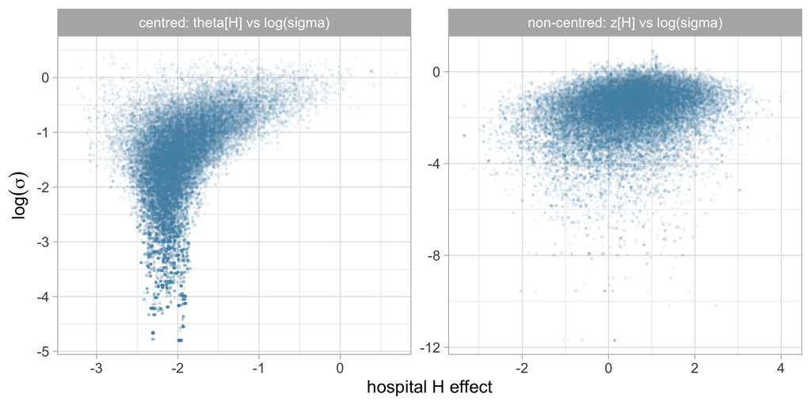

```r
dr_nc <- as.matrix(hier_fit); dr_c <- as.matrix(hier_fit_c)
bind_rows(
  tibble(parameterisation = "centred: theta[H] vs log(sigma)",
         effect = dr_c[, "theta[8]"], log_sigma = log(dr_c[, "sigma"])),
  tibble(parameterisation = "non-centred: z[H] vs log(sigma)",
         effect = dr_nc[, "z[8]"], log_sigma = log(dr_nc[, "sigma"]))) |>
  ggplot(aes(effect, log_sigma)) +
  geom_point(alpha = 0.05, size = 0.4, colour = "steelblue") +
  facet_wrap(~parameterisation, scales = "free") +
  labs(x = "hospital H effect", y = expression(log(sigma)))
```

In the centred version the draws form a **funnel**. When $\sigma$ is large, $\theta_H$ can vary widely; when $\sigma$ is small, every $\theta_j$ is forced close to $\mu$, and the neck of the funnel becomes very narrow. A sampler whose step sizes suit the wide top of the funnel cannot get far into the neck, so small values of $\sigma$ are visited rarely and in long, sticky stretches: this is what the low ESS and high $\widehat R$ for $\sigma$ are signalling. In the non-centred version, $z_j$ and $\sigma$ are independent in the prior, the pair plot is a shapeless cloud, and the sampler moves freely, including to very small values of $\sigma$.

Which parameterisation samples better depends on how much information the data carry about each group. With small groups, or a small $\sigma$, as here, the non-centred version is usually better; with large, informative groups the centred version can be better (Practical 5). The pair plot, not a rule of thumb, tells you which situation you are in.

Hierarchical models extend naturally to: multi-centre trials, repeated measurements on patients, small-area estimation, meta-analysis (studies as groups), and spatial models for disease mapping. In all of these the Bayesian formulation (with MCMC or INLA) is often the most practical way to fit the model and propagate all sources of uncertainty.

## 7.6 Reporting a Bayesian analysis

Following the Bayesian Analysis Reporting Guidelines (Kruschke, 2021), a report should include:

- the **model** (sampling model and all priors), with a justification of the priors and a prior predictive check where priors matter;
- the **computation**: software and version, samplers if non-default, number of chains, iterations, burn-in, and convergence diagnostics ($\widehat R$, ESS);
- **posterior summaries** on interpretable scales: medians or means, credible intervals (say which type), and posterior probabilities of clinically meaningful events;
- **model checks** (posterior predictive checks) and, where relevant, model comparison (LOO);
- a **sensitivity analysis** to the priors and to key modelling choices;
- **code and data** (or simulated data) to reproduce the analysis.

## 7.7 Where next

- `brms` fits the models of this lecture (and far more) with a formula interface on top of `Stan`; e.g. the hierarchical model is `brm(deaths | trials(n) ~ 1 + (1 | hospital), family = binomial, data = hosp)`.
- Missing data and measurement error are handled by treating unknown values as extra parameters to be sampled.
- Spatial and spatio-temporal models for disease mapping (`R-INLA`, `NIMBLE`’s CAR distributions).
- Bayesian adaptive clinical trial designs, which use posterior probabilities for interim decisions.

**NotePractical 5**

The full workflow on a logistic regression: prior predictive check, fit, diagnostics, odds ratios and predicted probabilities; posterior predictive checks and LOO comparison of Poisson and negative binomial models; a hierarchical model for multi-site data, comparing complete, no and partial pooling.

# Appendix A: Probability refresher

*Self-study material; based in part on Feelders, A.J. (2007), “Statistical Concepts”, in Berthold & Hand (eds.), Intelligent Data Analysis, 2<sup>nd</sup> ed., Springer.*

**Outcome space and events.** The outcome space $\Omega$ is the set of all possible outcomes of a random experiment; an event $A$ is a subset of $\Omega$. $\bar A=\Omega\setminus A$ is the complement.

**Interpretations of probability.** *Classical*: $P(A)=|A|/|\Omega|$ for equally likely outcomes. *Frequency*: $P(A)$ is the long-run relative frequency of $A$ in repetitions of the experiment. *Subjective*: $P(A)$ is a degree of belief. Bayesian statistics uses the subjective interpretation, which allows probability statements about non-repeatable things such as parameters. All three obey the same rules.

**Axioms (Kolmogorov).** (i) $P(A)\geq0$; (ii) $P(\Omega)=1$; (iii) if $A\cap B=\emptyset$, $P(A\cup B)=P(A)+P(B)$ (and similarly for countably many disjoint events). Everything else follows.

**Conditional probability and independence.** $P(B\mid A)=P(A\cap B)/P(A)$ for $P(A)>0$. $A$ and $B$ are independent if $P(A\cap B)=P(A)P(B)$, equivalently $P(B\mid A)=P(B)$.

**Law of total probability and Bayes’ rule.** If $B_1,\ldots,B_k$ partition $\Omega$: $P(A)=\sum_j P(A\mid B_j)P(B_j)$, and $P(B_i\mid A)=P(A\mid B_i)P(B_i)/\sum_jP(A\mid B_j)P(B_j)$.

**Random variables.** A random variable is a function $X:\Omega\to\mathbb R$. A discrete random variable has a probability mass function $p(x)=P(X=x)$ with $\sum_xp(x)=1$. A continuous random variable has a density $p(x)\geq0$ with $P(a<X\leq b)=\int_a^bp(x)dx$ and $\int p(x)dx=1$; note $p(x)$ may exceed 1, and $P(X=x)=0$ for every $x$.

**Expectation and variance.** $E[h(X)]=\sum_xh(x)p(x)$ or $\int h(x)p(x)dx$. $\mu=E[X]$; $\text{Var}(X)=E[(X-\mu)^2]=E[X^2]-\mu^2$.

**Joint, marginal, conditional.** For $(X,Y)$ with joint density $p(x,y)$: marginal $p(x)=\int p(x,y)\,dy$ (sum for discrete); conditional $p(y\mid x)=p(x,y)/p(x)$; independence iff $p(x,y)=p(x)p(y)$. Bayes’ rule for densities: $p(x\mid y)=p(y\mid x)p(x)/p(y)$.

**Change of variables.** If $\phi=g(\theta)$ with $g$ monotone and differentiable, then $p_\phi(\phi)=p_\theta\left(g^{-1}(\phi)\right)\left|\frac{d g^{-1}(\phi)}{d\phi}\right|$. This is why a prior that is flat for $\theta$ is generally not flat for $g(\theta)$ (Lecture 2). By simulation: draw $\theta^{(s)}$ and compute $g(\theta^{(s)})$.

**Useful distributions** (parameterised as in `R`):

| Distribution | Support | Mean | Variance | `R` |
| --- | --- | --- | --- | --- |
| $\text{Bin}(n,\pi)$ | $0,\ldots,n$ | $n\pi$ | $n\pi(1-\pi)$ | `dbinom(x, n, pi)` |
| $\text{Pois}(\lambda)$ | $0,1,\ldots$ | $\lambda$ | $\lambda$ | `dpois(x, lambda)` |
| $\text{NegBin}(r,p)$ | $0,1,\ldots$ | $r(1-p)/p$ | $r(1-p)/p^2$ | `dnbinom(x, size = r, prob = p)` |
| $\text{Beta}(a,b)$ | $[0,1]$ | $a/(a+b)$ | $ab/[(a+b)^2(a+b+1)]$ | `dbeta(x, a, b)` |
| $\text{Gamma}(a,b)$ | $(0,\infty)$ | $a/b$ | $a/b^2$ | `dgamma(x, shape = a, rate = b)` |
| $\mathcal N(\mu,\sigma^2)$ | $\mathbb R$ | $\mu$ | $\sigma^2$ | `dnorm(x, mu, sigma)` (SD!) |

The Beta$(a,b)$ density is $\frac{\Gamma(a+b)}{\Gamma(a)\Gamma(b)}\pi^{a-1}(1-\pi)^{b-1}$, with mode $\frac{a-1}{a+b-2}$ for $a,b>1$. The Gamma$(a,b)$ density is $\frac{b^a}{\Gamma(a)}\lambda^{a-1}e^{-b\lambda}$, with mode $(a-1)/b$ for $a\geq1$. $\Gamma(m)=(m-1)!$ for positive integers $m$.

# Appendix B: Conjugate derivations

## B.1 Beta-binomial, with the normalising constant

With $p(k\mid\pi)=\binom nk\pi^k(1-\pi)^{n-k}$ and $p(\pi)=\frac{1}{B(a,b)}\pi^{a-1}(1-\pi)^{b-1}$, where $B(a,b)=\frac{\Gamma(a)\Gamma(b)}{\Gamma(a+b)}=\int_0^1t^{a-1}(1-t)^{b-1}dt$:

$$p(k)=\int_0^1p(k\mid\pi)p(\pi)d\pi=\binom nk\frac{1}{B(a,b)}\int_0^1\pi^{a+k-1}(1-\pi)^{b+n-k-1}d\pi=\binom nk\frac{B(a+k,\,b+n-k)}{B(a,b)},$$

so

$$p(\pi\mid k)=\frac{p(k\mid\pi)p(\pi)}{p(k)}=\frac{1}{B(a+k,\,b+n-k)}\pi^{a+k-1}(1-\pi)^{b+n-k-1},$$

the $\text{Beta}(a+k,\,b+n-k)$ density. $p(k)$, the prior predictive distribution of $k$, is the **beta-binomial** distribution. The posterior mode (MAP) is $\frac{a+k-1}{a+b+n-2}$, the posterior mean $\frac{a+k}{a+b+n}$, and the posterior predictive probability that the next trial is a success is $P(\tilde Y=1\mid k)=E[\pi\mid k]=\frac{a+k}{a+b+n}$.

For $n$ i.i.d. Bernoulli trials the likelihood is $\prod_i\pi^{y_i}(1-\pi)^{1-y_i}=\pi^k(1-\pi)^{n-k}$ with $k=\sum_iy_i$: the same kernel, hence the same posterior. $k$ is a sufficient statistic.

## B.2 Gamma-Poisson and its posterior predictive distribution

Posterior: see Lecture 2. Posterior predictive, writing $a'=a+\sum y_i$, $b'=b+n$:

$$p(\tilde y\mid\mathbf y)=\int_0^\infty\frac{\lambda^{\tilde y}e^{-\lambda}}{\tilde y!}\,\frac{b'^{a'}}{\Gamma(a')}\lambda^{a'-1}e^{-b'\lambda}d\lambda
=\frac{b'^{a'}}{\Gamma(a')\,\tilde y!}\,\frac{\Gamma(a'+\tilde y)}{(b'+1)^{a'+\tilde y}}
=\frac{\Gamma(a'+\tilde y)}{\Gamma(a')\,\tilde y!}\left(\frac{b'}{b'+1}\right)^{a'}\left(\frac{1}{b'+1}\right)^{\tilde y},$$

which is $\text{NegBin}\left(r=a',\,p=\frac{b'}{b'+1}\right)$ in `R`’s parameterisation. Its variance, $\frac{a'}{b'}\left(1+\frac{1}{b'}\right)$, exceeds the Poisson variance $a'/b'$ because of uncertainty about $\lambda$.

## B.3 Jeffreys priors

$p_J(\theta)\propto\sqrt{I(\theta)}$ with Fisher information $I(\theta)=-E\left[\frac{\partial^2}{\partial\theta^2}\log p(Y\mid\theta)\,\middle|\,\theta\right]$.

*Binomial.* $\log p(y\mid\theta)=\text{const}+y\log\theta+(n-y)\log(1-\theta)$, so $\frac{\partial^2}{\partial\theta^2}\log p=-\frac{y}{\theta^2}-\frac{n-y}{(1-\theta)^2}$. With $E[Y]=n\theta$: $I(\theta)=\frac{n}{\theta}+\frac{n}{1-\theta}=\frac{n}{\theta(1-\theta)}$, hence $p_J(\theta)\propto\theta^{-1/2}(1-\theta)^{-1/2}$: a (proper) $\text{Beta}(\tfrac12,\tfrac12)$.

*Poisson ($n$ observations).* $I(\lambda)=n/\lambda$, so $p_J(\lambda)\propto\lambda^{-1/2}$, which is improper. The posterior $\text{Gamma}\left(\sum y_i+\tfrac12,\;n\right)$ is proper for any $n\geq1$.

## B.4 The normal model

**Mean, variance known.** Prior $\mu\sim\mathcal N(\mu_0,\tau_0^2)$, data $Y_i\sim_{\text{iid}}\mathcal N(\mu,\sigma^2)$. Completing the square in $\log p(\mu\mid\mathbf y)=\text{const}-\frac{(\mu-\mu_0)^2}{2\tau_0^2}-\sum_i\frac{(y_i-\mu)^2}{2\sigma^2}$ gives $\mu\mid\mathbf y\sim\mathcal N(\mu_n,\tau_n^2)$ with $1/\tau_n^2=1/\tau_0^2+n/\sigma^2$ and $\mu_n=\tau_n^2(\mu_0/\tau_0^2+n\bar y/\sigma^2)$.

**Conjugate prior, both unknown (normal-inverse-gamma).**

$$1/\sigma^2\sim\text{Gamma}\left(\tfrac{\nu_0}{2},\tfrac{\nu_0\sigma_0^2}{2}\right),\qquad\mu\mid\sigma^2\sim\mathcal N\left(\mu_0,\sigma^2/\kappa_0\right).$$

$\kappa_0$ and $\nu_0$ act as prior sample sizes for the mean and the variance. The posterior is of the same form with

$$\begin{aligned}
\kappa_n&=\kappa_0+n, & \mu_n&=\frac{\kappa_0\mu_0+n\bar y}{\kappa_n},\\
\nu_n&=\nu_0+n, & \nu_n\sigma_n^2&=\nu_0\sigma_0^2+(n-1)s^2+\frac{\kappa_0n}{\kappa_n}(\bar y-\mu_0)^2,
\end{aligned}$$

where $s^2$ is the sample variance. Integrating out $\sigma^2$, the marginal posterior of $\mu$ is a Student-$t$ with $\nu_n$ degrees of freedom, location $\mu_n$ and scale $\sigma_n/\sqrt{\kappa_n}$. (Derivation: Hoff, 2009, Section 5.3.)

**Semi-conjugate prior** (independent priors on $\mu$ and $\sigma^2$): full conditionals as in Lecture 2; joint posterior by Gibbs sampling (Lecture 3).

## B.5 Conjugate priors for one-parameter exponential families

If $p(y\mid\phi)=h(y)\,c(\phi)\,e^{\phi\,t(y)}$, then the prior $p(\phi\mid n_0,t_0)\propto c(\phi)^{n_0}e^{n_0t_0\phi}$ is conjugate:

$$p(\phi\mid\mathbf y)\propto c(\phi)^{n_0+n}\exp\left(\phi\left[n_0t_0+\textstyle\sum_it(y_i)\right]\right)
\;\Rightarrow\;
n_0\to n_0+n,\qquad t_0\to\frac{n_0t_0+\sum_it(y_i)}{n_0+n}.$$

$n_0$ is a prior sample size and $t_0$ a prior guess of the average of $t(Y)$; the posterior guess is the weighted average of $t_0$ and the sample average of $t(y_i)$. This is the general form of the “weighted average” pattern seen throughout Lecture 2. Binomial, Poisson, exponential, geometric and normal (one parameter at a time) models are all of this form; this connects directly to the exponential-family formulation of GLMs.

# Appendix C: Loss functions and Bayes estimators

The **posterior expected loss** of estimate $\hat\theta$ is $\rho(\hat\theta\mid\mathbf y)=\int L(\theta,\hat\theta)\,p(\theta\mid\mathbf y)\,d\theta$. The **Bayes estimator** minimises it for the observed $\mathbf y$. (It also minimises the *Bayes risk* $\int\rho(\hat\theta(\mathbf y)\mid\mathbf y)\,p(\mathbf y)\,d\mathbf y$, because the integrand is minimised pointwise in $\mathbf y$.)

- **Squared error**, $L=(\theta-\hat\theta)^2$: $\frac{d\rho}{d\hat\theta}=-2\int(\theta-\hat\theta)p(\theta\mid\mathbf y)d\theta=0\iff\hat\theta=E[\theta\mid\mathbf y]$.
- **Absolute error**, $L=|\theta-\hat\theta|$: $\frac{d\rho}{d\hat\theta}=P(\theta<\hat\theta\mid\mathbf y)-P(\theta>\hat\theta\mid\mathbf y)=0\iff\hat\theta=$ posterior median.
- **0-1 loss**, $L=0$ if $|\theta-\hat\theta|<\epsilon$ and $1$ otherwise: $\rho=1-P(|\theta-\hat\theta|<\epsilon\mid\mathbf y)$, minimised by the centre of the $2\epsilon$-window with most posterior mass; as $\epsilon\to0$ this is the posterior mode (for a smooth, unimodal posterior).

From MCMC output: posterior mean = `mean(draws)`, median = `median(draws)`; the mode requires a density estimate and is the least stable of the three.